# TFM

PAM50

```r
#Los genes que destacan en los graficos de barras por presentarse mutados en el 10% de los pacientes dentro de la clasificacion PAM50 son: TP53, PIK3CA, CDH1, GATA3, MUC16, AHNAK2, SYNE1
table(data$Pam50Subtype)
```

```
##
##  Basal   Her2   LumA   LumB Normal
##    308    236    696    474    184
```

```r
####LumA
P50LA<-apply(data_LumA,2,function(x){sum(!is.na(x))}) #extraemos datos para LumA
GATA3.LAm<-as.numeric(P50LA["GATA3"])
AHNAK2.LAm<-as.numeric(P50LA["AHNAK2"])
MUC16.LAm<-as.numeric(P50LA["MUC16"])
PIK3CA.LAm<-as.numeric(P50LA["PIK3CA"])
TP53.LAm<-as.numeric(P50LA["TP53"])
SYNE1.LAm<-as.numeric(P50LA["SYNE1"])
CDH1.LAm<-as.numeric(P50LA["CDH1"])
v1<-c(TP53.LAm,PIK3CA.LAm,GATA3.LAm,SYNE1.LAm,MUC16.LAm,AHNAK2.LAm,CDH1.LAm)

####LumB
P50LB<-apply(data_LumB,2,function(x){sum(!is.na(x))}) #extraemos datos para LumB
TP53.LBm<-as.numeric(P50LB["TP53"])
PIK3CA.LBm<-as.numeric(P50LB["PIK3CA"])
SYNE1.LBm<-as.numeric(P50LB["SYNE1"])
GATA3.LBm<-as.numeric(P50LB["GATA3"])
MUC16.LBm<-as.numeric(P50LB["MUC16"])
AHNAK2.LBm<-as.numeric(P50LB["AHNAK2"])
CDH1.LBm<-as.numeric(P50LB["CDH1"])
v2<-c(TP53.LBm,PIK3CA.LBm,SYNE1.LBm,GATA3.LBm,MUC16.LBm,AHNAK2.LBm,CDH1.LBm)

####Normal
P50N<-apply(data_Normal,2,function(x){sum(!is.na(x))})
TP53.Nm<-as.numeric(P50N["TP53"])
PIK3CA.Nm<-as.numeric(P50N["PIK3CA"])
SYNE1.Nm<-as.numeric(P50N["SYNE1"])
GATA3.Nm<-as.numeric(P50N["GATA3"])
MUC16.Nm<-as.numeric(P50N["MUC16"])
AHNAK2.Nm<-as.numeric(P50N["AHNAK2"])
CDH1.Nm<-as.numeric(P50N["CDH1"])
v3<-c(TP53.Nm,PIK3CA.Nm,SYNE1.Nm,GATA3.Nm,MUC16.Nm,AHNAK2.Nm,CDH1.Nm)

####Basal
P50B<-apply(data_Basal,2,function(x){sum(!is.na(x))})
TP53.Bm<-as.numeric(P50B["TP53"])
PIK3CA.Bm<-as.numeric(P50B["PIK3CA"])
SYNE1.Bm<-as.numeric(P50B["SYNE1"])
GATA3.Bm<-as.numeric(P50B["GATA3"])
MUC16.Bm<-as.numeric(P50B["MUC16"])
AHNAK2.Bm<-as.numeric(P50B["AHNAK2"])
CDH1.Bm<-as.numeric(P50LA["CDH1"])
v4<-c(TP53.Bm,PIK3CA.Bm,SYNE1.Bm,GATA3.Bm,MUC16.Bm,AHNAK2.Bm,CDH1.Bm)

####Her2
P50H2<-apply(data_Her2,2,function(x){sum(!is.na(x))})
TP53.H2m<-as.numeric(P50H2["TP53"])
PIK3CA.H2m<-as.numeric(P50H2["PIK3CA"])
SYNE1.H2m<-as.numeric(P50H2["SYNE1"])
GATA3.H2m<-as.numeric(P50H2["GATA3"])
MUC16.H2m<-as.numeric(P50H2["MUC16"])
AHNAK2.H2m<-as.numeric(P50H2["AHNAK2"])
CDH1.H2m<-as.numeric(P50LA["CDH1"])
v5<-c(TP53.H2m,PIK3CA.H2m,SYNE1.H2m,GATA3.H2m,MUC16.H2m,AHNAK2.H2m,CDH1.H2m)


matrix1<-matrix(ncol=7,nrow=5)
matrix1<-rbind(v1,v2,v3,v4,v5)
colnames(matrix1)<-c("TP53","PIK3CA","SYNE1","GATA3","MUC16","AHNAK2","CDH1")
rownames(matrix1)<-c("LumA","LumB","Basal","Normal","Her2")
matrix1[is.na(matrix1)] <- 0

chisq.test(matrix1) #Test
```

```
##
##  Pearson's Chi-squared test
##
## data:  matrix1
## X-squared = 519.66, df = 24, p-value < 2.2e-16
```

CLASIFICACION HISTOLOGICA:

```r
table(data$Histological.Type) #Subtipos
```

```
##
##          BENIGN            DCIS             IDC         IDC-MED         IDC-MUC
##               1               2            1503              31              42
##         IDC-TUB         IDC+ILC             ILC INVASIVE TUMOUR  OTHER INVASIVE
##              67              87             141               9              19
##            PHYL
##               0
```

```r
#Se eligen los genes: TP53,PIK3CA,MUC16,GATA3,AHNAK2,KMT2C, AHNAK
####BENIGN
HISTB<-apply(data_BENIGN,2,function(x){sum(!is.na(x))})
TP53.Bm<-as.numeric(HISTB["TP53"])
PIK3CA.Bm<-as.numeric(HISTB["PIK3CA"])
MUC16.Bm<-as.numeric(HISTB["MUC16"])
GATA3.Bm<-as.numeric(HISTB["GATA3"])
AHNAK2.Bm<-as.numeric(HISTB["AHNAK2"])
KMT2C.Bm<-as.numeric(HISTB["KMT2C"])
AHNAK.Bm<-as.numeric(HISTB["AHNAK"])
v1.2<-c(TP53.Bm,PIK3CA.Bm,MUC16.Bm,GATA3.Bm,KMT2C.Bm,AHNAK2.Bm,AHNAK.Bm)

####DCIS
HISTDCIS<-apply(data_DCIS,2,function(x){sum(!is.na(x))})
TP53.DCISm<-as.numeric(HISTDCIS["TP53"])
PIK3CA.DCISm<-as.numeric(HISTDCIS["PIK3CA"])
MUC16.DCISm<-as.numeric(HISTDCIS["MUC16"])
GATA3.DCISm<-as.numeric(HISTDCIS["GATA3"])
AHNAK2.DCISm<-as.numeric(HISTDCIS["AHNAK2"])
KMT2C.DCISm<-as.numeric(HISTDCIS["KMT2C"])
AHNAK.DCISm<-as.numeric(HISTDCIS["AHNAK"])
v2.2<-c(TP53.DCISm,PIK3CA.DCISm,MUC16.DCISm,GATA3.DCISm,KMT2C.DCISm,AHNAK2.DCISm,AHNAK.DCISm)

####IDC
HISTIDC<-apply(data_IDC,2,function(x){sum(!is.na(x))})
TP53.IDCm<-as.numeric(HISTIDC["TP53"])
PIK3CA.IDCm<-as.numeric(HISTIDC["PIK3CA"])
MUC16.IDCm<-as.numeric(HISTIDC["MUC16"])
GATA3.IDCm<-as.numeric(HISTIDC["GATA3"])
AHNAK2.IDCm<-as.numeric(HISTIDC["AHNAK2"])
KMT2C.IDCm<-as.numeric(HISTIDC["KMT2C"])
AHNAK.IDCm<-as.numeric(HISTIDC["AHNAK"])
v3.2<-c(TP53.IDCm,PIK3CA.IDCm,MUC16.IDCm,GATA3.IDCm,KMT2C.IDCm,AHNAK2.IDCm,AHNAK.IDCm)

####IDCMED
HISTIDCMED<-apply(data_IDCMED,2,function(x){sum(!is.na(x))})
TP53.IDCMEDm<-as.numeric(HISTIDCMED["TP53"])
PIK3CA.IDCMEDm<-as.numeric(HISTIDCMED["PIK3CA"])
MUC16.IDCMEDm<-as.numeric(HISTIDCMED["MUC16"])
GATA3.IDCMEDm<-as.numeric(HISTIDCMED["GATA3"])
AHNAK2.IDCMEDm<-as.numeric(HISTIDCMED["AHNAK2"])
KMT2C.IDCMEDm<-as.numeric(HISTIDCMED["KMT2C"])
AHNAK.IDCMEDm<-as.numeric(HISTIDCMED["AHNAK"])
v4.2<-c(TP53.IDCMEDm,PIK3CA.IDCMEDm,MUC16.IDCMEDm,GATA3.IDCMEDm,KMT2C.IDCMEDm,AHNAK2.IDCMEDm,AHNAK.IDCMEDm)

####IDCMUC
HISTIDCMUC<-apply(data_IDCMUC,2,function(x){sum(!is.na(x))})
TP53.IDCMUCm<-as.numeric(HISTIDCMUC["TP53"])
PIK3CA.IDCMUCm<-as.numeric(HISTIDCMUC["PIK3CA"])
MUC16.IDCMUCm<-as.numeric(HISTIDCMUC["MUC16"])
GATA3.IDCMUCm<-as.numeric(HISTIDCMUC["GATA3"])
AHNAK2.IDCMUCm<-as.numeric(HISTIDCMUC["AHNAK2"])
KMT2C.IDCMUCm<-as.numeric(HISTIDCMUC["KMT2C"])
AHNAK.IDCMUCm<-as.numeric(HISTIDCMUC["AHNAK"])
v5.2<-c(TP53.IDCMUCm,PIK3CA.IDCMUCm,MUC16.IDCMUCm,GATA3.IDCMUCm,KMT2C.IDCMUCm,AHNAK2.IDCMUCm,AHNAK.IDCMUCm)

####IDCTUB
HISTIDCTUB<-apply(data_IDCTUB,2,function(x){sum(!is.na(x))})
TP53.IDCTUBm<-as.numeric(HISTIDCTUB["TP53"])
PIK3CA.IDCTUBm<-as.numeric(HISTIDCTUB["PIK3CA"])
MUC16.IDCTUBm<-as.numeric(HISTIDCTUB["MUC16"])
GATA3.IDCTUBm<-as.numeric(HISTIDCTUB["GATA3"])
AHNAK2.IDCTUBm<-as.numeric(HISTIDCTUB["AHNAK2"])
KMT2C.IDCTUBm<-as.numeric(HISTIDCTUB["KMT2C"])
AHNAK.IDCTUBm<-as.numeric(HISTIDCTUB["AHNAK"])
v6.2<-c(TP53.IDCTUBm,PIK3CA.IDCTUBm,MUC16.IDCTUBm,GATA3.IDCTUBm,KMT2C.IDCTUBm,AHNAK2.IDCTUBm,AHNAK.IDCTUBm)


####IDC+ILC
HISTIDCILC<-apply(data_IDCILC,2,function(x){sum(!is.na(x))})
TP53.IDCILCm<-as.numeric(HISTIDCILC["TP53"])
PIK3CA.IDCILCm<-as.numeric(HISTIDCILC["PIK3CA"])
MUC16.IDCILCm<-as.numeric(HISTIDCILC["MUC16"])
GATA3.IDCILCm<-as.numeric(HISTIDCILC["GATA3"])
AHNAK2.IDCILCm<-as.numeric(HISTIDCILC["AHNAK2"])
KMT2C.IDCILCm<-as.numeric(HISTIDCILC["KMT2C"])
AHNAK.IDCILCm<-as.numeric(HISTIDCILC["AHNAK"])
v7.2<-c(TP53.IDCILCm,PIK3CA.IDCILCm,MUC16.IDCILCm,GATA3.IDCILCm,KMT2C.IDCILCm,AHNAK2.IDCILCm,AHNAK.IDCILCm)

####ILC
HISTILC<-apply(data_ILC,2,function(x){sum(!is.na(x))})
TP53.ILCm<-as.numeric(HISTILC["TP53"])
PIK3CA.ILCm<-as.numeric(HISTILC["PIK3CA"])
MUC16.ILCm<-as.numeric(HISTILC["MUC16"])
GATA3.ILCm<-as.numeric(HISTILC["GATA3"])
AHNAK2.ILCm<-as.numeric(HISTILC["AHNAK2"])
KMT2C.ILCm<-as.numeric(HISTILC["KMT2C"])
AHNAK.ILCm<-as.numeric(HISTILC["AHNAK"])
v8.2<-c(TP53.ILCm,PIK3CA.ILCm,MUC16.ILCm,GATA3.ILCm,KMT2C.ILCm,AHNAK2.ILCm,AHNAK.ILCm)


####INVASIVE

HISTIT<-apply(data_IT,2,function(x){sum(!is.na(x))})
TP53.ITm<-as.numeric(HISTIT["TP53"])
PIK3CA.ITm<-as.numeric(HISTIT["PIK3CA"])
MUC16.ITm<-as.numeric(HISTIT["MUC16"])
GATA3.ITm<-as.numeric(HISTIT["GATA3"])
AHNAK2.ITm<-as.numeric(HISTIT["AHNAK2"])
KMT2C.ITm<-as.numeric(HISTIT["KMT2C"])
AHNAK.ITm<-as.numeric(HISTIT["AHNAK"])
v9.2<-c(TP53.ITm,PIK3CA.ITm,MUC16.ITm,GATA3.ITm,KMT2C.ITm,AHNAK2.ITm,AHNAK.ITm)

####OTHER
HISTOI<-apply(data_OI,2,function(x){sum(!is.na(x))})
TP53.OIm<-as.numeric(HISTOI["TP53"])
PIK3CA.OIm<-as.numeric(HISTOI["PIK3CA"])
MUC16.OIm<-as.numeric(HISTOI["MUC16"])
GATA3.OIm<-as.numeric(HISTOI["GATA3"])
AHNAK2.OIm<-as.numeric(HISTOI["AHNAK2"])
KMT2C.OIm<-as.numeric(HISTOI["KMT2C"])
AHNAK.OIm<-as.numeric(HISTOI["AHNAK"])
v10.2<-c(TP53.OIm,PIK3CA.OIm,MUC16.OIm,GATA3.OIm,KMT2C.OIm,AHNAK2.OIm,AHNAK.OIm)

#Test Chi2 para clasificacion Histologica:

matrix2<-matrix(ncol=7,nrow=10)
matrix2<-rbind(v1.2,v2.2,v3.2,v4.2,v5.2,v6.2,v7.2,v8.2,v9.2,v10.2)
colnames(matrix2)<-c("TP53","PIK3CA","MUC16","GATA3","KMT2C","AHNAK2","AHNAK")
rownames(matrix2)<-c("BENIGN","DCIS","IDC","IDC-MED","IDC-MUC","IDC-TUB","IDC+ILC","ILC","IT","OI")
matrix2[is.na(matrix2)] <- 0

chisq.test(matrix2)
```

```
##
##  Pearson's Chi-squared test
##
## data:  matrix2
## X-squared = 156.55, df = 54, p-value = 6.381e-12
```

Nuevamente, el resultado sale significativo.

CLAUDIN SUBTYPE:

```r
table(data$ClaudinSubtype) #Subtipos
```

```
##
##       Basal claudin-low        Her2        LumA        LumB      Normal
##         199         199         220         679         461         140
```

```r
#Los genes a estudiar son: PIK3CA, AHNAK2, SYNE1, TP53, MUC16, GATA3, DNAH11


####BASAL
CLAUB<-apply(data_Basalc,2,function(x){sum(!is.na(x))})
SYNE1.Bcm<-as.numeric(CLAUB["SYNE1"])
PIK3CA.Bcm<-as.numeric(CLAUB["PIK3CA"])
MUC16.Bcm<-as.numeric(CLAUB["MUC16"])
GATA3.Bcm<-as.numeric(CLAUB["GATA3"])
AHNAK2.Bcm<-as.numeric(CLAUB["AHNAK2"])
TP53.Bcm<-as.numeric(CLAUB["TP53"])
DNAH11.Bcm<-as.numeric(CLAUB["DNAH11"])
v1.3<-c(SYNE1.Bcm,PIK3CA.Bcm,MUC16.Bcm,GATA3.Bcm,TP53.Bcm,AHNAK2.Bcm,DNAH11.Bcm)


####CLAUDIN LOW
CLAUCL<-apply(data_clau,2,function(x){sum(!is.na(x))})
SYNE1.clm<-as.numeric(CLAUCL["SYNE1"])
PIK3CA.clm<-as.numeric(CLAUCL["PIK3CA"])
MUC16.clm<-as.numeric(CLAUCL["MUC16"])
GATA3.clm<-as.numeric(CLAUCL["GATA3"])
AHNAK2.clm<-as.numeric(CLAUCL["AHNAK2"])
TP53.clm<-as.numeric(CLAUCL["TP53"])
DNAH11.clm<-as.numeric(CLAUCL["DNAH11"])
v2.3<-c(SYNE1.clm,PIK3CA.clm,MUC16.clm,GATA3.clm,TP53.clm,AHNAK2.clm,DNAH11.clm)


####HER2
CLAUHER2<-apply(data_Her2c,2,function(x){sum(!is.na(x))})
SYNE1.hercm<-as.numeric(CLAUHER2["SYNE1"])
PIK3CA.hercm<-as.numeric(CLAUHER2["PIK3CA"])
MUC16.hercm<-as.numeric(CLAUHER2["MUC16"])
GATA3.hercm<-as.numeric(CLAUHER2["GATA3"])
AHNAK2.hercm<-as.numeric(CLAUHER2["AHNAK2"])
TP53.hercm<-as.numeric(CLAUCL["TP53"])
DNAH11.hercm<-as.numeric(CLAUCL["DNAH11"])
v3.3<-c(SYNE1.hercm,PIK3CA.hercm,MUC16.hercm,GATA3.hercm,TP53.hercm,AHNAK2.hercm,DNAH11.hercm)


####LUM-A
CLAULUMA<-apply(data_LumAc,2,function(x){sum(!is.na(x))})
SYNE1.clam<-as.numeric(CLAULUMA["SYNE1"])
PIK3CA.clam<-as.numeric(CLAULUMA["PIK3CA"])
MUC16.clam<-as.numeric(CLAULUMA["MUC16"])
GATA3.clam<-as.numeric(CLAULUMA["GATA3"])
AHNAK2.clam<-as.numeric(CLAULUMA["AHNAK2"])
TP53.clam<-as.numeric(CLAULUMA["TP53"])
DNAH11.clam<-as.numeric(CLAULUMA["DNAH11"])
v4.3<-c(SYNE1.clam,PIK3CA.clam,MUC16.clam,GATA3.clam,TP53.clam,AHNAK2.clam,DNAH11.clam)


####LUM-B
CLAULUMB<-apply(data_LumBc,2,function(x){sum(!is.na(x))})
SYNE1.clbm<-as.numeric(CLAULUMB["SYNE1"])
PIK3CA.clbm<-as.numeric(CLAULUMB["PIK3CA"])
MUC16.clbm<-as.numeric(CLAULUMB["MUC16"])
GATA3.clbm<-as.numeric(CLAULUMB["GATA3"])
AHNAK2.clbm<-as.numeric(CLAULUMB["AHNAK2"])
TP53.clbm<-as.numeric(CLAULUMB["TP53"])
DNAH11.clbm<-as.numeric(CLAULUMB["DNAH11"])
v5.3<-c(SYNE1.clbm,PIK3CA.clbm,MUC16.clbm,GATA3.clbm,TP53.clbm,AHNAK2.clbm,DNAH11.clbm)


####NORMAL
CLAUN<-apply(data_Normalc,2,function(x){sum(!is.na(x))})
SYNE1.clnm<-as.numeric(CLAUN["SYNE1"])
PIK3CA.clnm<-as.numeric(CLAUN["PIK3CA"])
MUC16.clnm<-as.numeric(CLAUN["MUC16"])
GATA3.clnm<-as.numeric(CLAUN["GATA3"])
AHNAK2.clnm<-as.numeric(CLAUN["AHNAK2"])
TP53.clnm<-as.numeric(CLAUN["TP53"])
DNAH11.clnm<-as.numeric(CLAUN["DNAH11"])
v6.3<-c(SYNE1.clnm,PIK3CA.clnm,MUC16.clnm,GATA3.clnm,TP53.clnm,AHNAK2.clnm,DNAH11.clnm)

matrix3<-matrix(ncol=7,nrow=6)
matrix3<-rbind(v1.3,v2.3,v3.3,v4.3,v5.3,v6.3)
colnames(matrix3)<-c("SYNE1","PIK3CA","MUC16","GATA3","TP53","AHNAK2","DNAH11")
rownames(matrix3)<-c("BASAL","CLAUDIN-LOW","HER2","LUMA","LUMB","NORMAL")
matrix3[is.na(matrix3)] <- 0

chisq.test(matrix3)
```

```
##
##  Pearson's Chi-squared test
##
## data:  matrix3
## X-squared = 490.71, df = 30, p-value < 2.2e-16
```

HER2 / PR /ER

```r
###HER2+
HER2p<-apply(data_HER2p,2,function(x){sum(!is.na(x))})
TP53.her2p<-as.numeric(HER2p["TP53"])
PIK3CA.her2p<-as.numeric(HER2p["PIK3CA"])
MUC16.her2p<-as.numeric(HER2p["MUC16"])
GATA3.her2p<-as.numeric(HER2p["GATA3"])
AHNAK2.her2p<-as.numeric(HER2p["AHNAK2"])
SYNE1.her2p<-as.numeric(HER2p["SYNE1"])
KMT2c.her2p<-as.numeric(HER2p["KMT2C"])
v7.1<-c(TP53.her2p,PIK3CA.her2p,MUC16.her2p,GATA3.her2p,AHNAK2.her2p,SYNE1.her2p,KMT2c.her2p)
###HER2-
HER2n<-apply(data_HER2n,2,function(x){sum(!is.na(x))})
TP53.her2n<-as.numeric(HER2n["TP53"])
PIK3CA.her2n<-as.numeric(HER2n["PIK3CA"])
MUC16.her2n<-as.numeric(HER2n["MUC16"])
GATA3.her2n<-as.numeric(HER2n["GATA3"])
AHNAK2.her2n<-as.numeric(HER2n["AHNAK2"])
SYNE1.her2n<-as.numeric(HER2n["SYNE1"])
KMT2c.her2n<-as.numeric(HER2n["KMT2C"])
v7.2<-c(TP53.her2n,PIK3CA.her2n,MUC16.her2n,GATA3.her2n,AHNAK2.her2n,SYNE1.her2n,KMT2c.her2n)
###ER+
ERp<-apply(data_ERp,2,function(x){sum(!is.na(x))})
TP53.erp<-as.numeric(ERp["TP53"])
PIK3CA.erp<-as.numeric(ERp["PIK3CA"])
MUC16.erp<-as.numeric(ERp["MUC16"])
GATA3.erp<-as.numeric(ERp["GATA3"])
AHNAK2.erp<-as.numeric(ERp["AHNAK2"])
SYNE1.erp<-as.numeric(ERp["SYNE1"])
KMT2C.erp<-as.numeric(ERp["KMT2c"])
v7.3<-c(TP53.erp,PIK3CA.erp,MUC16.erp,GATA3.erp,AHNAK2.erp,SYNE1.erp,KMT2C.erp)
###ER-
ERn<-apply(data_ERn,2,function(x){sum(!is.na(x))})
TP53.ern<-as.numeric(ERn["TP53"])
PIK3CA.ern<-as.numeric(ERn["PIK3CA"])
MUC16.ern<-as.numeric(ERn["MUC16"])
GATA3.ern<-as.numeric(ERn["GATA3"])
AHNAK2.ern<-as.numeric(ERn["AHNAK2"])
SYNE1.ern<-as.numeric(ERn["SYNE1"])
KMT2C.ern<-as.numeric(ERn["KMT2C"])
v7.4<-c(TP53.ern,PIK3CA.ern,MUC16.ern,GATA3.ern,AHNAK2.ern,SYNE1.ern,KMT2C.ern)
###PR+
PRp<-apply(data_PRp,2,function(x){sum(!is.na(x))})
TP53.prp<-as.numeric(PRp["TP53"])
PIK3CA.prp<-as.numeric(PRp["PIK3CA"])
MUC16.prp<-as.numeric(PRp["MUC16"])
GATA3.prp<-as.numeric(PRp["GATA3"])
AHNAK2.prp<-as.numeric(PRp["AHNAK2"])
SYNE1.prp<-as.numeric(PRp["SYNE1"])
KMT2C.prp<-as.numeric(PRp["KMT2C"])
v7.5<-c(TP53.prp,PIK3CA.prp,MUC16.prp,GATA3.prp,AHNAK2.prp,SYNE1.prp,KMT2C.prp)
###PR-
PRn<-apply(data_PRn,2,function(x){sum(!is.na(x))})
TP53.prn<-as.numeric(PRn["TP53"])
PIK3CA.prn<-as.numeric(PRn["PIK3CA"])
MUC16.prn<-as.numeric(PRn["MUC16"])
GATA3.prn<-as.numeric(PRn["GATA3"])
AHNAK2.prn<-as.numeric(PRn["AHNAK2"])
SYNE1.prn<-as.numeric(PRn["SYNE1"])
KMT2C.prn<-as.numeric(PRn["KMT2C"])
v7.6<-c(TP53.prn,PIK3CA.prn,MUC16.prn,GATA3.prn,AHNAK2.prn,SYNE1.prn,KMT2C.prn)
```

```r
#HER2
matrix4<-matrix(ncol=7,nrow=2)
matrix4<-rbind(v7.1,v7.2)
colnames(matrix4)<-c("TP53","PIK3CA","MUC16","GATA3","AHNAK2","SYNE1","KMT2C")
rownames(matrix4)<-c("HER2+","HER2-")
matrix4[is.na(matrix4)] <- 0

chisq.test(matrix4)
```

```
##
##  Pearson's Chi-squared test
##
## data:  matrix4
## X-squared = 89.034, df = 6, p-value < 2.2e-16
```

```r
#ER
matrix5<-matrix(ncol=7,nrow=2)
matrix5<-rbind(v7.3,v7.4)
colnames(matrix5)<-c("TP53","PIK3CA","MUC16","GATA3","AHNAK2","SYNE1","KMT2C")
rownames(matrix5)<-c("ER+","ER-")
matrix5[is.na(matrix5)] <- 0

chisq.test(matrix5)
```

```
##
##  Pearson's Chi-squared test
##
## data:  matrix5
## X-squared = 470.76, df = 6, p-value < 2.2e-16
```

```r
#PR
matrix6<-matrix(ncol=7,nrow=2)
matrix6<-rbind(v7.5,v7.6)
colnames(matrix6)<-c("TP53","PIK3CA","MUC16","GATA3","AHNAK2","SYNE1","KMT2C")
rownames(matrix6)<-c("PR+","PR-")
matrix6[is.na(matrix6)] <- 0

chisq.test(matrix6)
```

```
##
##  Pearson's Chi-squared test
##
## data:  matrix6
## X-squared = 253.72, df = 6, p-value < 2.2e-16
```

A partir de este momento seguimos el estudio valorando la supervivencia de los pacientes. Es interesante ver la supervivencia entre los pacientes que presentan mutacion y los que no.

Primeramente, se va a valorar la supervivencia en todos los pacientes que presentan mutacion y sin ella en los genes mas representativos, sin diferenciar subtipos.

```r
#TP53
#Generamos las 3 variables que son tiempo, tp53 y muerte por cancer
status <- data$DeathBreast #aislamos la informacion sobre la muerte de los pacientes
time <- data$T/30 #tiempo en meses
tp53 <- data$TP53 #datos para el gen TP53

sum(table(tp53)) #recuento de los que tienen mutacion (diferente a NA)
```

```
## [1] 658
```

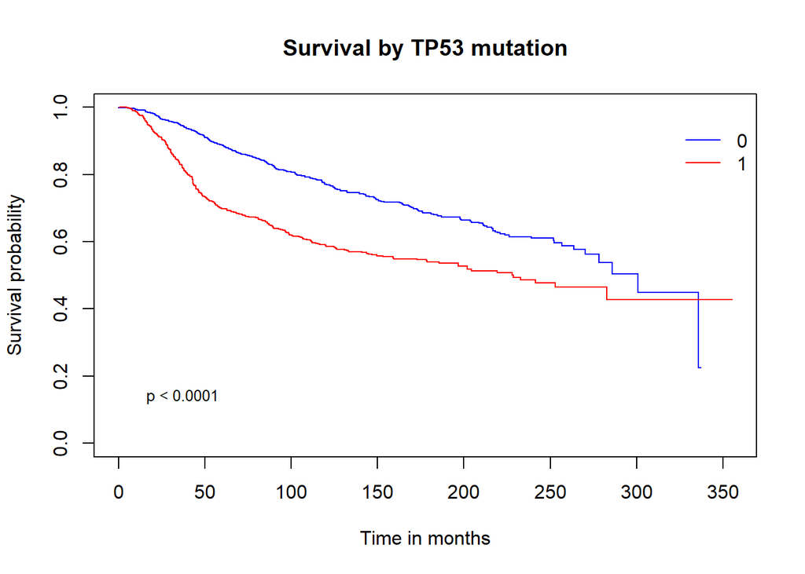

```r
tp53<-ifelse(is.na(tp53), 0,1) #Ahora 1 es mutacion y 0 no.

dfsurv <- data.frame(time, status, tp53) #Crear una tabla con las 3 variables que debemos analizar para este gen
fit <- survfit(Surv(time, status) ~ tp53, data = dfsurv) #tabla con los eventos dados para pacientes mutados y no mutados en TP53

pval <- surv_pvalue(fit) #p-valor para la diferencia entre pacientes mutados y no mutados y su supervivencia

survplot(Surv(time, status) ~ tp53, data = dfsurv, col=c("blue", "red"), show.nrisk=F, hr.pos=NA, legend.pos = "topright", stitle=NA, cex=0.5,main = "Survival by TP53 mutation",ylab="Survival probability", xlab="Time in months")
legend(x=0, y=0.2, legend=as.character(pval$pval.txt), cex=0.8, box.lty = 0)
```

```r
#Representacion de la supervivencia de pacientes con mutacion en TP53 y sin ella para todas las clasificaciones
```

```r
#Supervivencia para el gen PIK3CA
pik3ca<- data$PIK3CA
sum(table(pik3ca))
```

```
## [1] 795
```

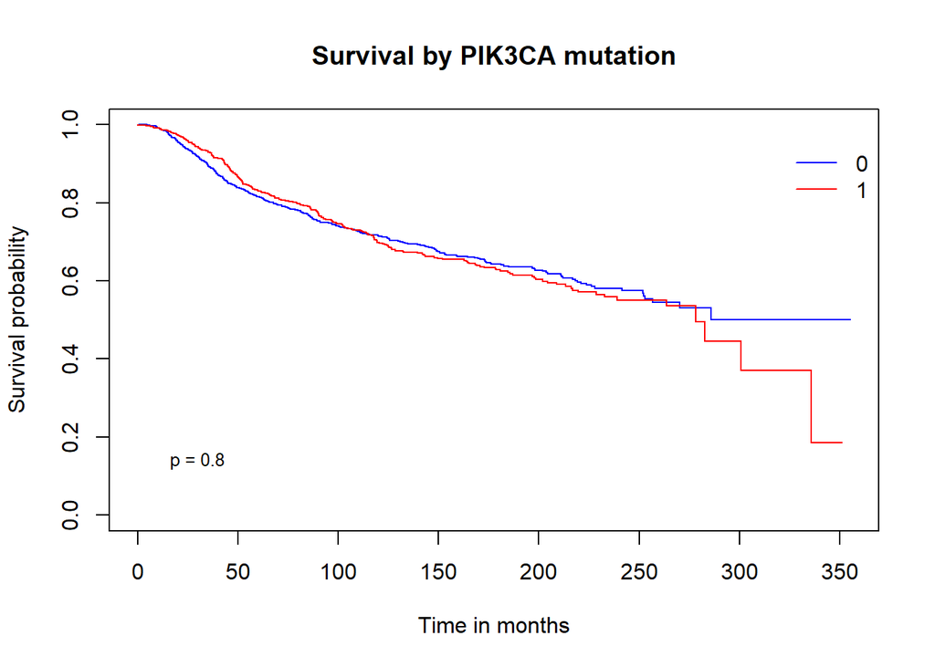

```r
pik3ca<-ifelse(is.na(pik3ca),0,1)
dfsurv2 <- data.frame(time, status, pik3ca)
fit2 <- survfit(Surv(time, status) ~ pik3ca, data = dfsurv2)
pval <- surv_pvalue(fit2)
survplot(Surv(time, status) ~ pik3ca, data = dfsurv2, col=c("blue", "red"), show.nrisk=F, hr.pos=NA, legend.pos = "topright", stitle=NA, cex=0.5,main = "Survival by PIK3CA mutation",ylab="Survival probability", xlab="Time in months")
legend(x=0, y=0.2, legend=as.character(pval$pval.txt), cex=0.8, box.lty = 0)
```

```r
#AHNAK2
ahnak2<- data$AHNAK2
sum(table(ahnak2))
```

```
## [1] 310
```

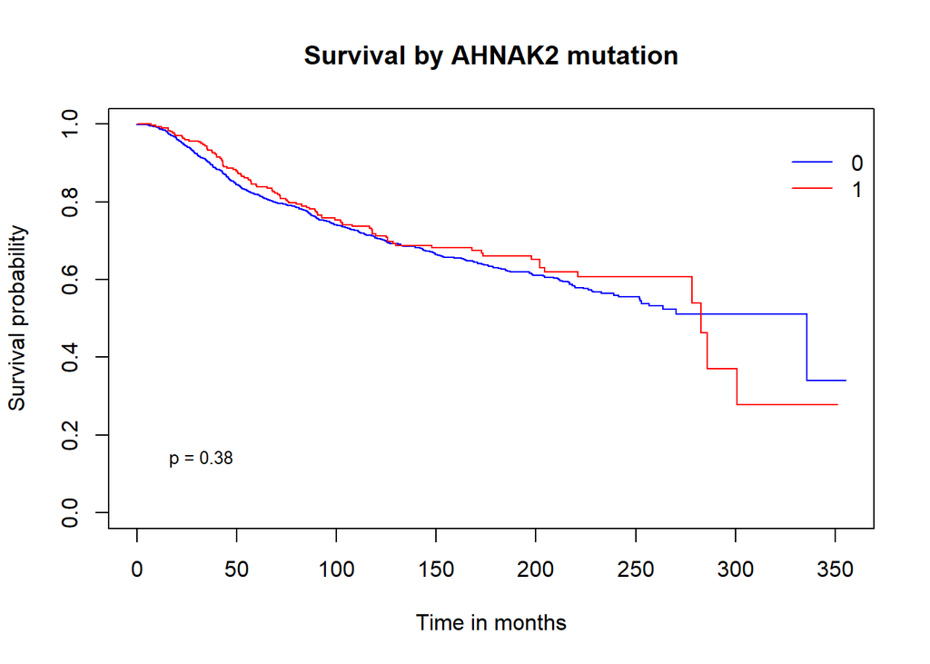

```r
ahnak2<-ifelse(is.na(ahnak2),0,1)
dfsurv3 <- data.frame(time, status, ahnak2)
fit3 <- survfit(Surv(time, status) ~ ahnak2, data = dfsurv3)
pval <- surv_pvalue(fit3)
survplot(Surv(time, status) ~ ahnak2, data = dfsurv3, col=c("blue", "red"), show.nrisk=F, hr.pos=NA, legend.pos = "topright", stitle=NA, cex=0.5,main = "Survival by AHNAK2 mutation",ylab="Survival probability", xlab="Time in months")
legend(x=0, y=0.2, legend=as.character(pval$pval.txt), cex=0.8, box.lty = 0)
```

```r
#GATA3
gata3<- data$GATA3
sum(table(gata3))
```

```
## [1] 230
```

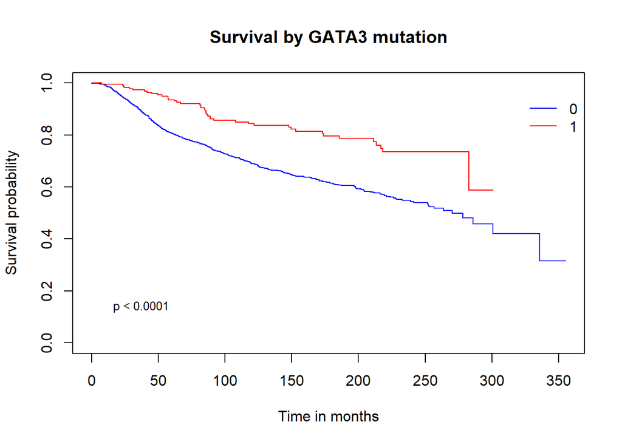

```r
gata3<-ifelse(is.na(gata3),0,1)
dfsurv4 <- data.frame(time, status, gata3)
fit4 <- survfit(Surv(time, status) ~ gata3, data = dfsurv4)
pval <- surv_pvalue(fit4)
survplot(Surv(time, status) ~ gata3, data = dfsurv4, col=c("blue", "red"), show.nrisk=F, hr.pos=NA, legend.pos = "topright", stitle=NA, cex=0.5,main = "Survival by GATA3 mutation",ylab="Survival probability", xlab="Time in months")
legend(x=0, y=0.2, legend=as.character(pval$pval.txt), cex=0.8, box.lty = 0)
```

```r
#MUC16
muc16<- data$MUC16
sum(table(muc16))
```

```
## [1] 326
```

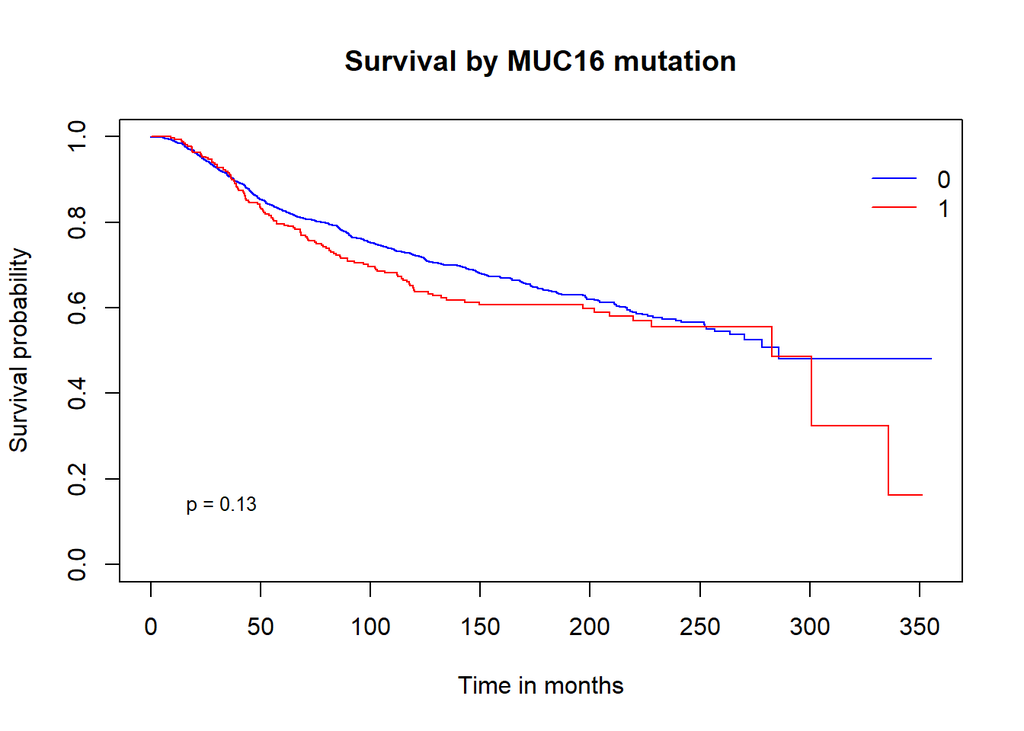

```r
muc16<-ifelse(is.na(muc16),0,1)
dfsurv5<- data.frame(time, status, muc16)
fit5 <- survfit(Surv(time, status) ~ muc16, data = dfsurv5)
pval <- surv_pvalue(fit5)
survplot(Surv(time, status) ~ muc16, data = dfsurv5, col=c("blue", "red"), show.nrisk=F, hr.pos=NA, legend.pos = "topright", stitle=NA, cex=0.5,main = "Survival by MUC16 mutation",ylab="Survival probability", xlab="Time in months")
legend(x=0, y=0.2, legend=as.character(pval$pval.txt), cex=0.8, box.lty = 0)
```

```r
#CDH1
cdh1<- data$CDH1
sum(table(cdh1))
```

```
## [1] 170
```

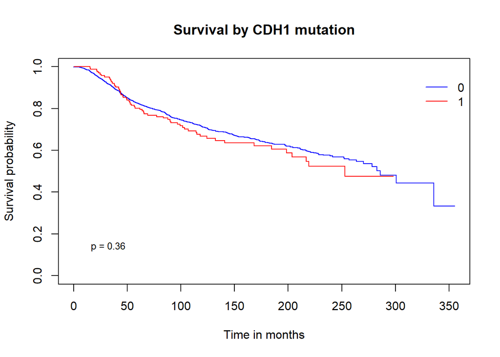

```r
cdh1<-ifelse(is.na(cdh1),0,1)
dfsurv6<- data.frame(time, status, cdh1)
fit6 <- survfit(Surv(time, status) ~ cdh1, data = dfsurv6)
pval <- surv_pvalue(fit6)
survplot(Surv(time, status) ~ cdh1, data = dfsurv6, col=c("blue", "red"), show.nrisk=F, hr.pos=NA, legend.pos = "topright", stitle=NA, cex=0.5,main = "Survival by CDH1 mutation",ylab="Survival probability", xlab="Time in months")
legend(x=0, y=0.2, legend=as.character(pval$pval.txt), cex=0.8, box.lty = 0)
```

```r
#SYNE1
syne1<- data$SYNE1
sum(table(syne1))
```

```
## [1] 231
```

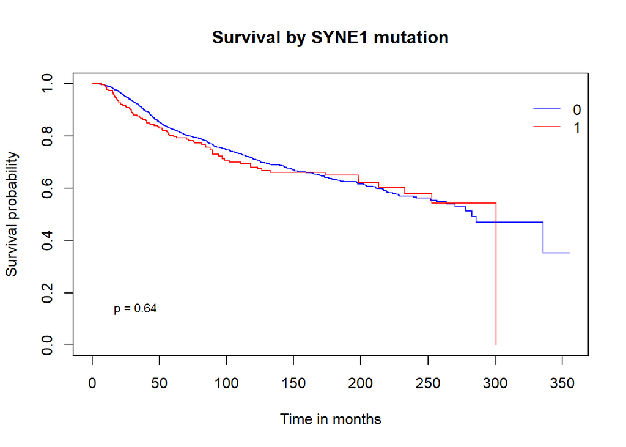

```r
syne1<-ifelse(is.na(syne1),0,1)
dfsurv7<- data.frame(time, status, syne1)
fit7 <- survfit(Surv(time, status) ~ syne1, data = dfsurv7)
pval <- surv_pvalue(fit7)
survplot(Surv(time, status) ~ syne1, data = dfsurv7, col=c("blue", "red"), show.nrisk=F, hr.pos=NA, legend.pos = "topright", stitle=NA, cex=0.5,main = "Survival by SYNE1 mutation",ylab="Survival probability", xlab="Time in months")
legend(x=0, y=0.2, legend=as.character(pval$pval.txt), cex=0.8, box.lty = 0)
```

```r
#AHNAK
ahnak<- data$AHNAK
sum(table(ahnak))
```

```
## [1] 175
```

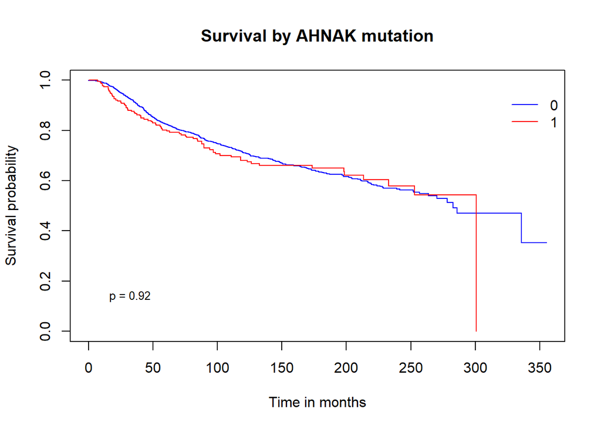

```r
ahnak<-ifelse(is.na(ahnak),0,1)
dfsurv8<- data.frame(time, status, ahnak)
fit8 <- survfit(Surv(time, status) ~ ahnak, data = dfsurv8)
pval <- surv_pvalue(fit8)
survplot(Surv(time, status) ~ syne1, data = dfsurv8, col=c("blue", "red"), show.nrisk=F, hr.pos=NA, legend.pos = "topright", stitle=NA, cex=0.5,main = "Survival by AHNAK mutation",ylab="Survival probability", xlab="Time in months")
legend(x=0, y=0.2, legend=as.character(pval$pval.txt), cex=0.8, box.lty = 0)
```

```r
#KMT2C
kmt2c<- data$KMT2C
sum(table(kmt2c))
```

```
## [1] 231
```

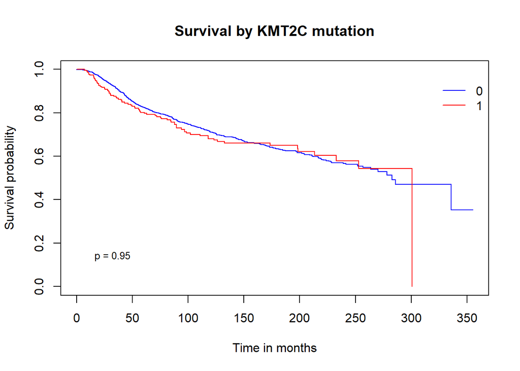

```r
kmt2c<-ifelse(is.na(kmt2c),0,1)
dfsurv9<- data.frame(time, status, kmt2c)
fit9 <- survfit(Surv(time, status) ~ kmt2c, data = dfsurv9)
pval <- surv_pvalue(fit9)
survplot(Surv(time, status) ~ syne1, data = dfsurv9, col=c("blue", "red"), show.nrisk=F, hr.pos=NA, legend.pos = "topright", stitle=NA, cex=0.5,main = "Survival by KMT2C mutation",ylab="Survival probability", xlab="Time in months")
legend(x=0, y=0.2, legend=as.character(pval$pval.txt), cex=0.8, box.lty = 0)
```

Evaluando los pacientes sun atender a subtipos unicamente salen significativos TP53 y GATA3, por lo que es interesante valorarlo por subtipos.

Evaluacion de supervivencia por clasificaciones:

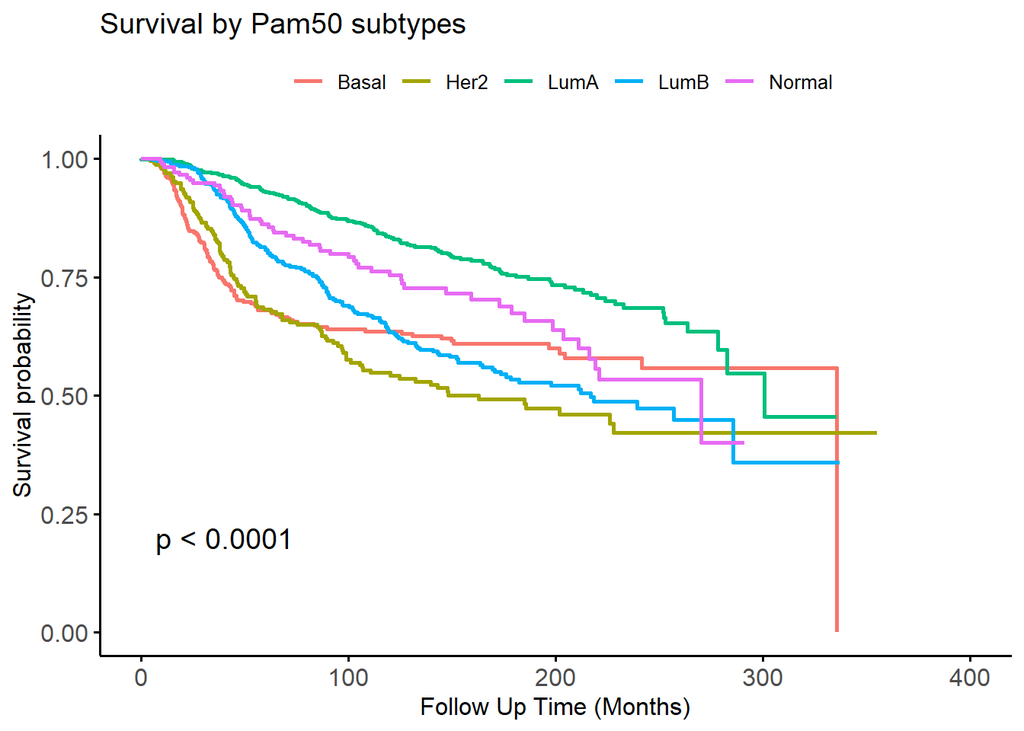

```r
#PAM50 en todos sus subtipos

status <- data$DeathBreast #aislamos la informacion sobre la muerte de los pacientes
time <- data$T/30 #tiempo en meses
dfsurvp50 <- data.frame(time, status, subtype=data$Pam50Subtype) #Variables a representar
fitt <- survfit(Surv(time, status) ~ subtype, data = dfsurvp50) #Enfrentar variables y subtipos
pval <- surv_pvalue(fitt) #Pvalor
ggsurvplot(fitt, title="Survival by Pam50 subtypes", xlab = "Follow Up Time (Months)", conf.int = FALSE, pval=TRUE, pval.method=FALSE, risk.table=FALSE, risk.table.pos="out", risk.table.col="black", risk.table.y.text.col=FALSE, tables.theme = theme_cleantable(), legend.labs=c("Basal","Her2", "LumA", "LumB", "Normal"), font.tickslab = c(12), legend.title="", ggtheme = theme_classic2(base_size=12, base_family = "Arial"), font.family = "Arial", linetype=1, censor=F) #Representar
```

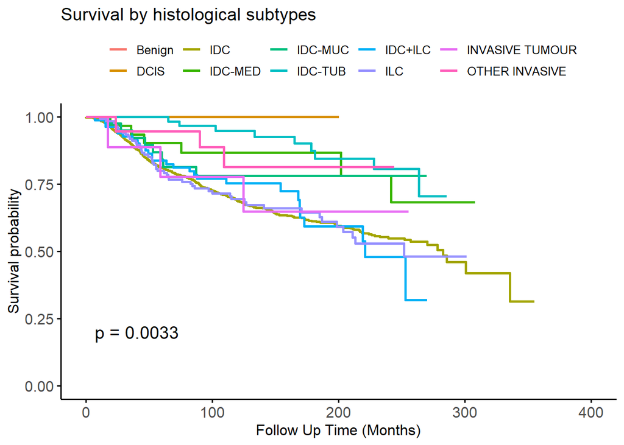

```r
#Histologica
dfsurvh<- data.frame(time, status, subtype=data$Histological.Type)
fitt <- survfit(Surv(time, status) ~ subtype, data = dfsurvh)
pval <- surv_pvalue(fitt)
ggsurvplot(fitt, title="Survival by histological subtypes", xlab = "Follow Up Time (Months)", conf.int = FALSE, pval=TRUE, pval.method=FALSE, risk.table=FALSE, risk.table.pos="out", risk.table.col="black", risk.table.y.text.col=FALSE, tables.theme = theme_cleantable(), legend.labs=c("Benign","DCIS", "IDC", "IDC-MED", "IDC-MUC","IDC-TUB","IDC+ILC","ILC","INVASIVE TUMOUR","OTHER INVASIVE"), font.tickslab = c(12), legend.title="", ggtheme = theme_classic2(base_size=12, base_family = "Arial"), font.family = "Arial", linetype=1, censor=F)
```

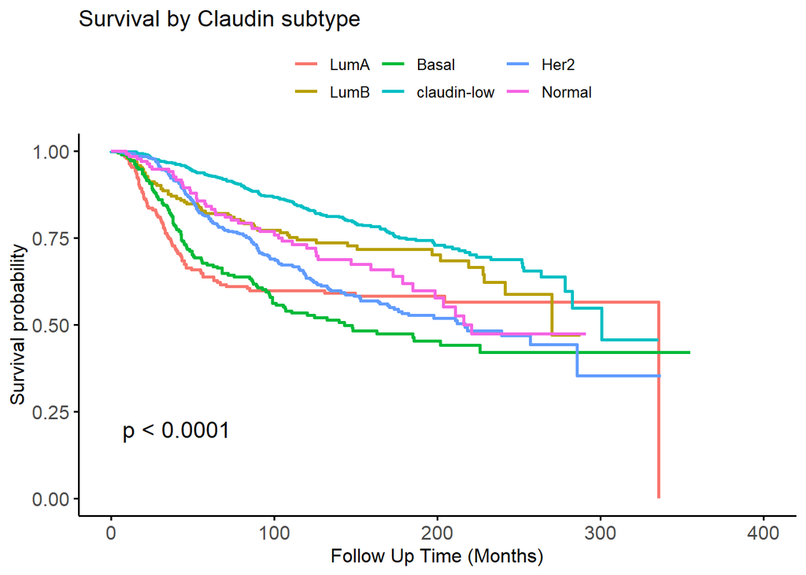

```r
#Claudin subtype
dfsurvh<- data.frame(time, status, subtype=data$ClaudinSubtype)
fitt <- survfit(Surv(time, status) ~ subtype, data = dfsurvh)
pval <- surv_pvalue(fitt)
ggsurvplot(fitt, title="Survival by Claudin subtype", xlab = "Follow Up Time (Months)", conf.int = FALSE, pval=TRUE, pval.method=FALSE, risk.table=FALSE, risk.table.pos="out", risk.table.col="black", risk.table.y.text.col=FALSE, tables.theme = theme_cleantable(), legend.labs=c("LumA","LumB", "Basal", "claudin-low", "Her2","Normal"), font.tickslab = c(12), legend.title="", ggtheme = theme_classic2(base_size=12, base_family = "Arial"), font.family = "Arial", linetype=1, censor=F)
```

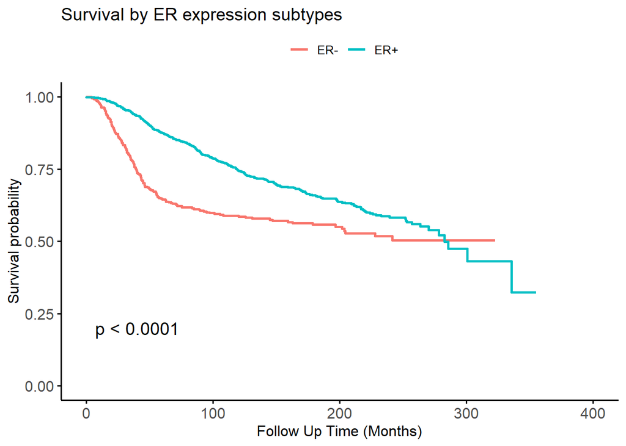

```r
#ER+ y ER-
dfsurvER<- data.frame(time, status, subtype=data$ER.Expr)
fitt <- survfit(Surv(time, status) ~ subtype, data = dfsurvER)
pval <- surv_pvalue(fitt)
ggsurvplot(fitt, title="Survival by ER expression subtypes", xlab = "Follow Up Time (Months)", conf.int = FALSE, pval=TRUE, pval.method=FALSE, risk.table=FALSE, risk.table.pos="out", risk.table.col="black", risk.table.y.text.col=FALSE, tables.theme = theme_cleantable(), legend.labs=c("ER-","ER+"), font.tickslab = c(12), legend.title="", ggtheme = theme_classic2(base_size=12, base_family = "Arial"), font.family = "Arial", linetype=1, censor=F)
```

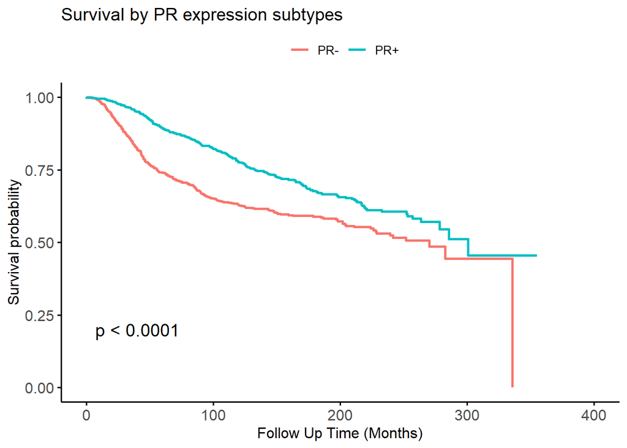

```r
#PR+ y PR-
dfsurvPR<- data.frame(time, status, subtype=data$PR.Expr)
fitt <- survfit(Surv(time, status) ~ subtype, data = dfsurvPR)
pval <- surv_pvalue(fitt)
ggsurvplot(fitt, title="Survival by PR expression subtypes", xlab = "Follow Up Time (Months)", conf.int = FALSE, pval=TRUE, pval.method=FALSE, risk.table=FALSE, risk.table.pos="out", risk.table.col="black", risk.table.y.text.col=FALSE, tables.theme = theme_cleantable(), legend.labs=c("PR-","PR+"), font.tickslab = c(12), legend.title="", ggtheme = theme_classic2(base_size=12, base_family = "Arial"), font.family = "Arial", linetype=1, censor=F)
```

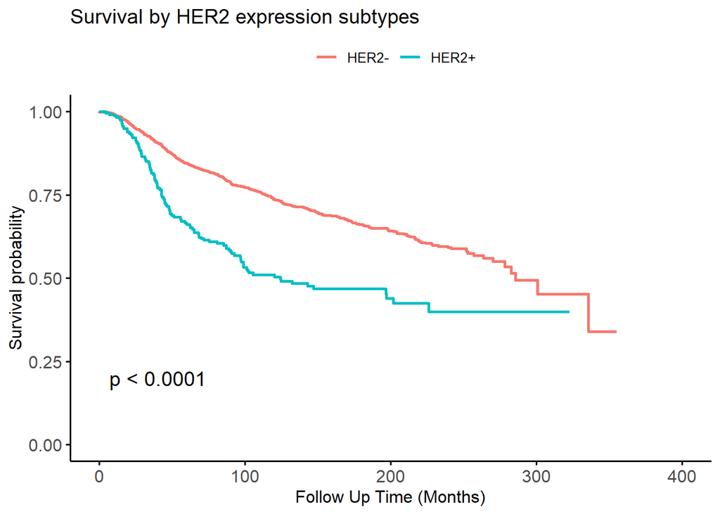

```r
#HER2+ y HER2-
dfsurvHER<- data.frame(time, status, subtype=data$Her2.Expr)
fitt <- survfit(Surv(time, status) ~ subtype, data = dfsurvHER)
pval <- surv_pvalue(fitt)
ggsurvplot(fitt, title="Survival by HER2 expression subtypes", xlab = "Follow Up Time (Months)", conf.int = FALSE, pval=TRUE, pval.method=FALSE, risk.table=FALSE, risk.table.pos="out", risk.table.col="black", risk.table.y.text.col=FALSE, tables.theme = theme_cleantable(), legend.labs=c("HER2-","HER2+"), font.tickslab = c(12), legend.title="", ggtheme = theme_classic2(base_size=12, base_family = "Arial"), font.family = "Arial", linetype=1, censor=F)
```

Ahora vamos a ver la supervivencia de los pacientes pertenecientes a cada subtipo de PAM50 con mutacion en cada uno de los genes y sin la misma:

ANALISIS DE SUPERVIVENCIA EN PAM50 PARA PACIENTES LUMA:

```r
###MUC16 en LUMA
data.PAM50.LumA<-data[data$Pam50Subtype=="LumA",c("Pam50Subtype","DeathBreast","T","MUC16","TP53","PIK3CA","GATA3","AHNAK2","SYNE1","CDH1")] #Voy a aislar primero LumA para los 2 genes que quiero analizar primero
status <- data.PAM50.LumA$DeathBreast #aislamos la informacion sobre la muerte de los pacientes
time <- data.PAM50.LumA$T/30 #tiempo en meses

LumA.MUC16 <- data.PAM50.LumA$MUC16 #datos para el gen MUC16

sum(table(LumA.MUC16)) #recuento de los que tienen mutacion (diferente a NA)
```

```
## [1] 113
```

```r
LumA.MUC16<-ifelse(is.na(LumA.MUC16), 0,1) #Ahora 1 es mutacion y 0 no.

dfsurv <- data.frame(time, status, LumA.MUC16) #Crear una tabla con las 3 variables que debemos analizar para este gen
head(dfsurv)
```

|  | time | status | LumA.MUC16 |
| --- | --- | --- | --- |
| 1 | 274.3667 | 0 | 0 |
| 2 | 112.6667 | 0 | 0 |
| 3 | 115.6333 | 0 | 0 |
| 4 | 116.9333 | 0 | 1 |
| 5 | 172.9000 | 0 | 0 |
| 6 | 193.9667 | 0 | 0 |

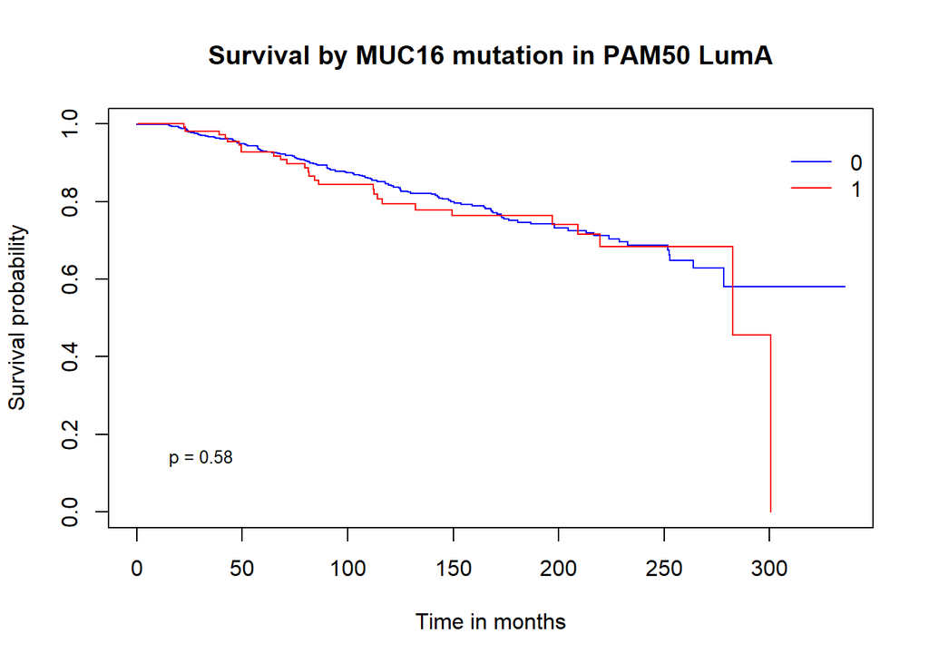

```r
#MUC16
fit <- survfit(Surv(time, status) ~ LumA.MUC16, data = dfsurv) #tabla con los eventos dados para pacientes mutados y no mutados en TP53

pval <- surv_pvalue(fit) #p-valor para la diferencia entre pacientes mutados y no mutados y su supervivencia

survplot(Surv(time, status) ~ LumA.MUC16, data = dfsurv, col=c("blue", "red"), show.nrisk=F, hr.pos=NA, legend.pos = "topright", stitle=NA, cex=0.5,main = "Survival by MUC16 mutation in PAM50 LumA",ylab="Survival probability", xlab="Time in months")
legend(x=0, y=0.2, legend=as.character(pval$pval.txt), cex=0.8, box.lty = 0)
```

```r
###TP53
LumA.TP53 <- data.PAM50.LumA$TP53
sum(table(LumA.TP53))
```

```
## [1] 82
```

```r
LumA.TP53<-ifelse(is.na(LumA.TP53), 0,1)
dfsurv <- data.frame(time, status, LumA.TP53)
head(dfsurv)
```

|  | time | status | LumA.TP53 |
| --- | --- | --- | --- |
| 1 | 274.3667 | 0 | 0 |
| 2 | 112.6667 | 0 | 0 |
| 3 | 115.6333 | 0 | 0 |
| 4 | 116.9333 | 0 | 0 |
| 5 | 172.9000 | 0 | 0 |
| 6 | 193.9667 | 0 | 1 |

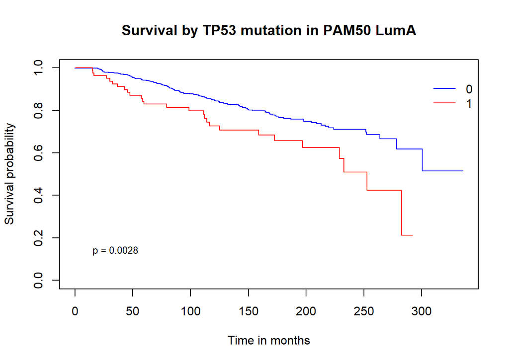

```r
fit <- survfit(Surv(time, status) ~ LumA.TP53, data = dfsurv)
pval <- surv_pvalue(fit)

survplot(Surv(time, status) ~ LumA.TP53, data = dfsurv, col=c("blue", "red"), show.nrisk=F, hr.pos=NA, legend.pos = "topright", stitle=NA, cex=0.5,main = "Survival by TP53 mutation in PAM50 LumA",ylab="Survival probability", xlab="Time in months")
legend(x=0, y=0.2, legend=as.character(pval$pval.txt), cex=0.8, box.lty = 0)
```

```r
###PIK3CA
LumA.PIK3CA <- data.PAM50.LumA$PIK3CA
sum(table(LumA.PIK3CA))
```

```
## [1] 396
```

```r
LumA.PIK3CA<-ifelse(is.na(LumA.PIK3CA), 0,1)
dfsurv <- data.frame(time, status, LumA.PIK3CA)
head(dfsurv)
```

|  | time | status | LumA.PIK3CA |
| --- | --- | --- | --- |
| 1 | 274.3667 | 0 | 0 |
| 2 | 112.6667 | 0 | 0 |
| 3 | 115.6333 | 0 | 1 |
| 4 | 116.9333 | 0 | 1 |
| 5 | 172.9000 | 0 | 1 |
| 6 | 193.9667 | 0 | 0 |

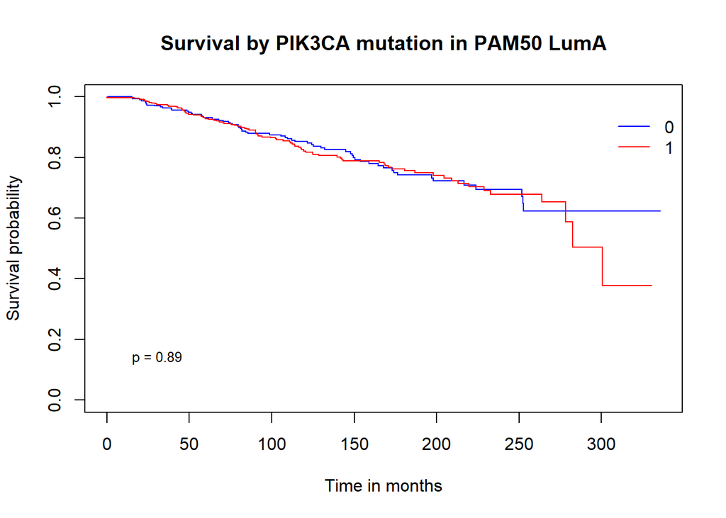

```r
fit <- survfit(Surv(time, status) ~ LumA.PIK3CA, data = dfsurv)
pval <- surv_pvalue(fit)
survplot(Surv(time, status) ~ LumA.PIK3CA, data = dfsurv, col=c("blue", "red"), show.nrisk=F, hr.pos=NA, legend.pos = "topright", stitle=NA, cex=0.5,main = "Survival by PIK3CA mutation in PAM50 LumA",ylab="Survival probability", xlab="Time in months")
legend(x=0, y=0.2, legend=as.character(pval$pval.txt), cex=0.8, box.lty = 0)
```

```r
###AHNAK2
LumA.AHNAK2 <- data.PAM50.LumA$AHNAK2
sum(table(LumA.AHNAK2))
```

```
## [1] 107
```

```r
LumA.AHNAK2<-ifelse(is.na(LumA.AHNAK2), 0,1)
dfsurv <- data.frame(time, status, LumA.AHNAK2)
head(dfsurv)
```

|  | time | status | LumA.AHNAK2 |
| --- | --- | --- | --- |
| 1 | 274.3667 | 0 | 0 |
| 2 | 112.6667 | 0 | 1 |
| 3 | 115.6333 | 0 | 0 |
| 4 | 116.9333 | 0 | 0 |
| 5 | 172.9000 | 0 | 0 |
| 6 | 193.9667 | 0 | 0 |

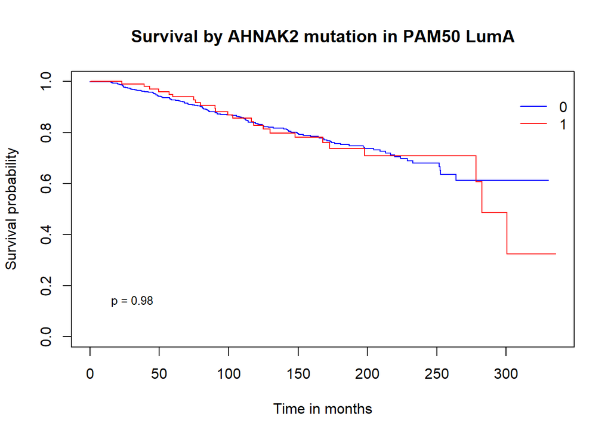

```r
fit <- survfit(Surv(time, status) ~ LumA.AHNAK2, data = dfsurv)
pval <- surv_pvalue(fit)
survplot(Surv(time, status) ~ LumA.AHNAK2, data = dfsurv, col=c("blue", "red"), show.nrisk=F, hr.pos=NA, legend.pos = "topright", stitle=NA, cex=0.5,main = "Survival by AHNAK2 mutation in PAM50 LumA",ylab="Survival probability", xlab="Time in months")
legend(x=0, y=0.2, legend=as.character(pval$pval.txt), cex=0.8, box.lty = 0)
```

```r
###SYNE1
LumA.SYNE1 <- data.PAM50.LumA$SYNE1
sum(table(LumA.SYNE1))
```

```
## [1] 63
```

```r
LumA.SYNE1<-ifelse(is.na(LumA.SYNE1), 0,1)
dfsurv <- data.frame(time, status, LumA.SYNE1)
head(dfsurv)
```

|  | time | status | LumA.SYNE1 |
| --- | --- | --- | --- |
| 1 | 274.3667 | 0 | 0 |
| 2 | 112.6667 | 0 | 0 |
| 3 | 115.6333 | 0 | 0 |
| 4 | 116.9333 | 0 | 0 |
| 5 | 172.9000 | 0 | 1 |
| 6 | 193.9667 | 0 | 0 |

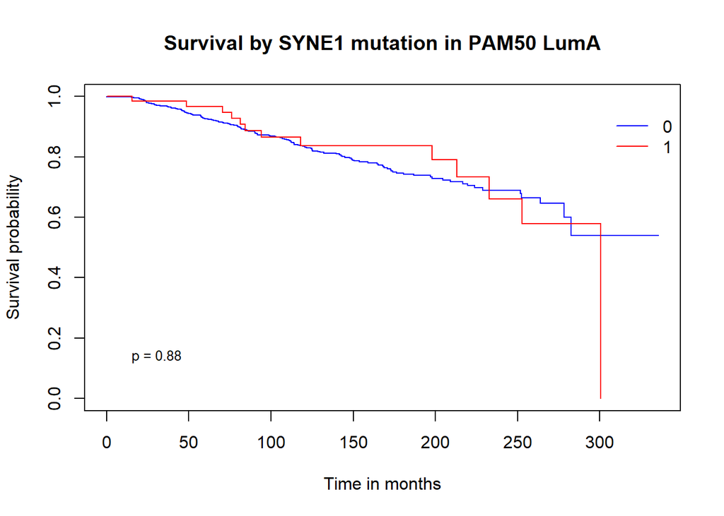

```r
fit <- survfit(Surv(time, status) ~ LumA.SYNE1, data = dfsurv)
pval <- surv_pvalue(fit)
survplot(Surv(time, status) ~ LumA.SYNE1, data = dfsurv, col=c("blue", "red"), show.nrisk=F, hr.pos=NA, legend.pos = "topright", stitle=NA, cex=0.5,main = "Survival by SYNE1 mutation in PAM50 LumA",ylab="Survival probability", xlab="Time in months")
legend(x=0, y=0.2, legend=as.character(pval$pval.txt), cex=0.8, box.lty = 0)
```

```r
###CDH1
LumA.CDH1 <- data.PAM50.LumA$CDH1
sum(table(LumA.CDH1))
```

```
## [1] 85
```

```r
LumA.CDH1<-ifelse(is.na(LumA.CDH1), 0,1)
dfsurv <- data.frame(time, status, LumA.CDH1)
head(dfsurv)
```

|  | time | status | LumA.CDH1 |
| --- | --- | --- | --- |
| 1 | 274.3667 | 0 | 0 |
| 2 | 112.6667 | 0 | 1 |
| 3 | 115.6333 | 0 | 0 |
| 4 | 116.9333 | 0 | 0 |
| 5 | 172.9000 | 0 | 1 |
| 6 | 193.9667 | 0 | 0 |

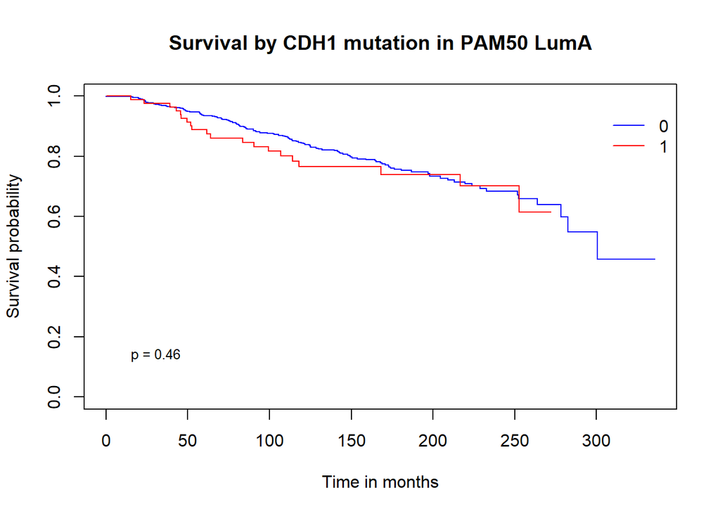

```r
fit <- survfit(Surv(time, status) ~ LumA.CDH1, data = dfsurv)
pval <- surv_pvalue(fit)
survplot(Surv(time, status) ~ LumA.CDH1, data = dfsurv, col=c("blue", "red"), show.nrisk=F, hr.pos=NA, legend.pos = "topright", stitle=NA, cex=0.5,main = "Survival by CDH1 mutation in PAM50 LumA",ylab="Survival probability", xlab="Time in months")
legend(x=0, y=0.2, legend=as.character(pval$pval.txt), cex=0.8, box.lty = 0)
```

```r
###GATA3
LumA.GATA3 <- data.PAM50.LumA$GATA3
sum(table(LumA.GATA3))
```

```
## [1] 134
```

```r
LumA.GATA3<-ifelse(is.na(LumA.GATA3), 0,1)
dfsurv <- data.frame(time, status, LumA.GATA3)
head(dfsurv)
```

|  | time | status | LumA.GATA3 |
| --- | --- | --- | --- |
| 1 | 274.3667 | 0 | 0 |
| 2 | 112.6667 | 0 | 0 |
| 3 | 115.6333 | 0 | 0 |
| 4 | 116.9333 | 0 | 0 |
| 5 | 172.9000 | 0 | 0 |
| 6 | 193.9667 | 0 | 0 |

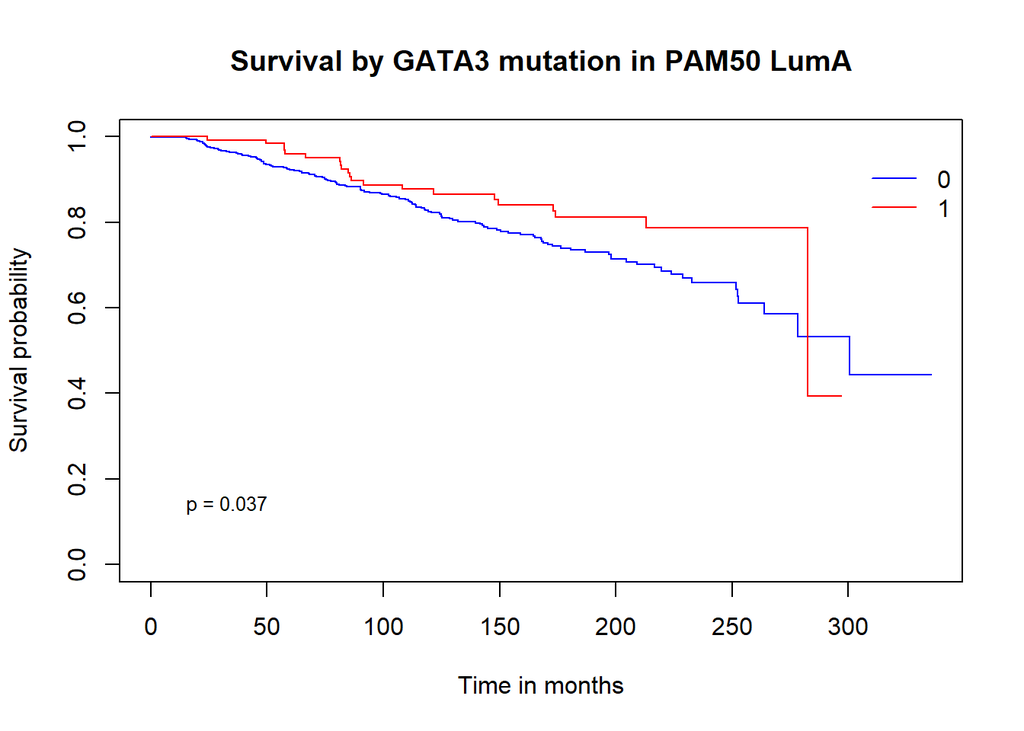

```r
fit <- survfit(Surv(time, status) ~ LumA.GATA3, data = dfsurv)
pval <- surv_pvalue(fit)
survplot(Surv(time, status) ~ LumA.GATA3, data = dfsurv, col=c("blue", "red"), show.nrisk=F, hr.pos=NA, legend.pos = "topright", stitle=NA, cex=0.5,main = "Survival by GATA3 mutation in PAM50 LumA",ylab="Survival probability", xlab="Time in months")
legend(x=0, y=0.2, legend=as.character(pval$pval.txt), cex=0.8, box.lty = 0)
```

SUPERVIVENCIA EN PACIENTES LUMB

```r
##MUC16

data.PAM50.LumB<-data[data$Pam50Subtype=="LumB",c("Pam50Subtype","DeathBreast","T","MUC16","TP53","GATA3","PIK3CA","AHNAK2","SYNE1", "CDH1")]
status <- data.PAM50.LumB$DeathBreast
time <- data.PAM50.LumB$T/30 #tiempo en meses
LumB.MUC16 <- data.PAM50.LumB$MUC16 #datos para el gen MUC16

sum(table(LumB.MUC16)) #recuento de los que tienen mutacion (diferente a NA)
```

```
## [1] 74
```

```r
LumB.MUC16<-ifelse(is.na(LumB.MUC16), 0,1) #Ahora 1 es mutacion y 0 no.

dfsurv <- data.frame(time, status, LumB.MUC16) #Crear una tabla con las 3 variables que debemos analizar para este gen
head(dfsurv)
```

|  | time | status | LumB.MUC16 |
| --- | --- | --- | --- |
| 1 | 81.13333 | 0 | 0 |
| 2 | 105.46667 | 0 | 0 |
| 3 | 45.33333 | 0 | 0 |
| 4 | 97.40000 | 0 | 0 |
| 5 | 85.86667 | 1 | 0 |
| 6 | 163.16667 | 0 | 0 |

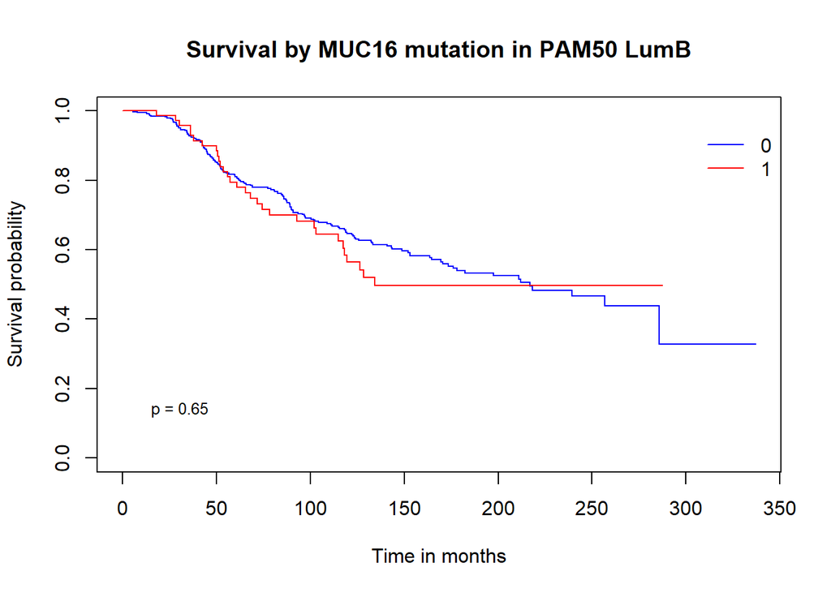

```r
fit <- survfit(Surv(time, status) ~ LumB.MUC16, data = dfsurv) #tabla con los eventos dados para pacientes mutados y no mutados en TP53

pval <- surv_pvalue(fit) #p-valor para la diferencia entre pacientes mutados y no mutados y su supervivencia

survplot(Surv(time, status) ~ LumB.MUC16, data = dfsurv, col=c("blue", "red"), show.nrisk=F, hr.pos=NA, legend.pos = "topright", stitle=NA, cex=0.5,main = "Survival by MUC16 mutation in PAM50 LumB",ylab="Survival probability", xlab="Time in months")
legend(x=0, y=0.2, legend=as.character(pval$pval.txt), cex=0.8, box.lty = 0)
```

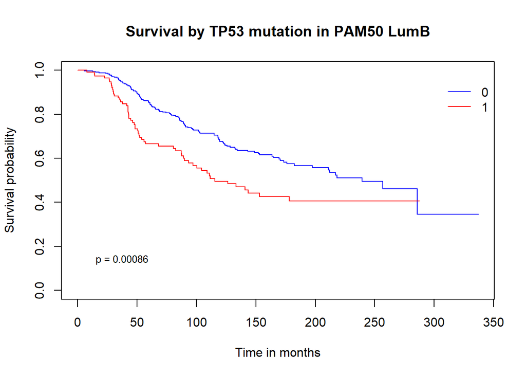

```r
##TP53
LumB.TP53 <- data.PAM50.LumB$TP53
LumB.TP53<-ifelse(is.na(LumB.TP53), 0,1)
dfsurv <- data.frame(time, status, LumB.TP53)
fit <- survfit(Surv(time, status) ~ LumB.TP53, data = dfsurv)
pval <- surv_pvalue(fit)

survplot(Surv(time, status) ~ LumB.TP53, data = dfsurv, col=c("blue", "red"), show.nrisk=F, hr.pos=NA, legend.pos = "topright", stitle=NA, cex=0.5,main = "Survival by TP53 mutation in PAM50 LumB",ylab="Survival probability", xlab="Time in months")
legend(x=0, y=0.2, legend=as.character(pval$pval.txt), cex=0.8, box.lty = 0)
```

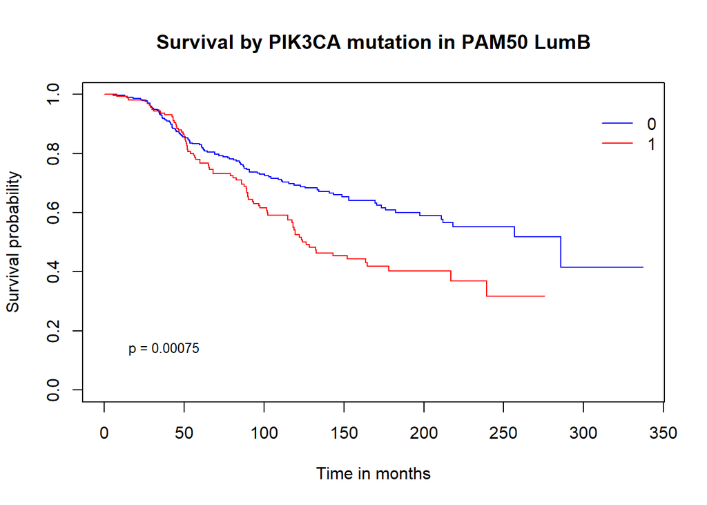

```r
##PIK3CA
LumB.PIK3CA <- data.PAM50.LumB$PIK3CA
LumB.PIK3CA<-ifelse(is.na(LumB.PIK3CA), 0,1)
dfsurv <- data.frame(time, status, LumB.PIK3CA)
fit <- survfit(Surv(time, status) ~ LumB.PIK3CA, data = dfsurv)
pval <- surv_pvalue(fit)

survplot(Surv(time, status) ~ LumB.PIK3CA, data = dfsurv, col=c("blue", "red"), show.nrisk=F, hr.pos=NA, legend.pos = "topright", stitle=NA, cex=0.5,main = "Survival by PIK3CA mutation in PAM50 LumB",ylab="Survival probability", xlab="Time in months")
legend(x=0, y=0.2, legend=as.character(pval$pval.txt), cex=0.8, box.lty = 0)
```

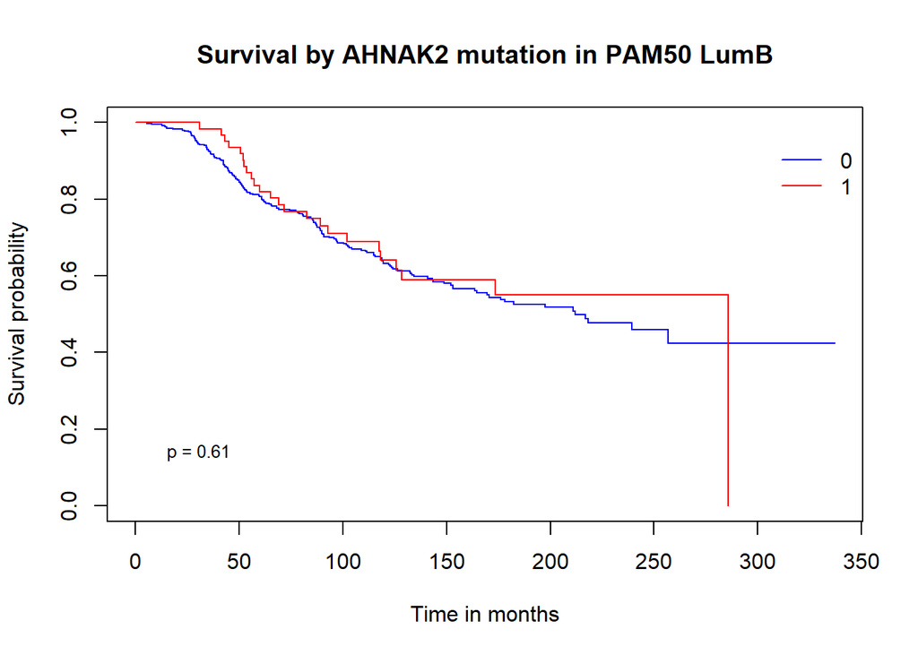

```r
##AHNAK2
LumB.AHNAK2 <- data.PAM50.LumB$AHNAK2
LumB.AHNAK2<-ifelse(is.na(LumB.AHNAK2), 0,1)
dfsurv <- data.frame(time, status, LumB.AHNAK2)
fit <- survfit(Surv(time, status) ~ LumB.AHNAK2, data = dfsurv)
pval <- surv_pvalue(fit)

survplot(Surv(time, status) ~ LumB.AHNAK2, data = dfsurv, col=c("blue", "red"), show.nrisk=F, hr.pos=NA, legend.pos = "topright", stitle=NA, cex=0.5,main = "Survival by AHNAK2 mutation in PAM50 LumB",ylab="Survival probability", xlab="Time in months")
legend(x=0, y=0.2, legend=as.character(pval$pval.txt), cex=0.8, box.lty = 0)
```

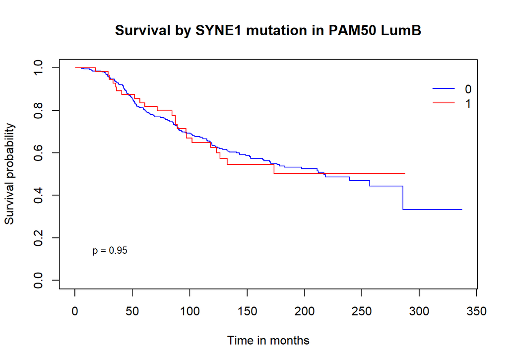

```r
##SYNE1
LumB.SYNE1 <- data.PAM50.LumB$SYNE1
LumB.SYNE1<-ifelse(is.na(LumB.SYNE1), 0,1)
dfsurv <- data.frame(time, status, LumB.SYNE1)
fit <- survfit(Surv(time, status) ~ LumB.SYNE1, data = dfsurv)
pval <- surv_pvalue(fit)

survplot(Surv(time, status) ~ LumB.SYNE1, data = dfsurv, col=c("blue", "red"), show.nrisk=F, hr.pos=NA, legend.pos = "topright", stitle=NA, cex=0.5,main = "Survival by SYNE1 mutation in PAM50 LumB",ylab="Survival probability", xlab="Time in months")
legend(x=0, y=0.2, legend=as.character(pval$pval.txt), cex=0.8, box.lty = 0)
```

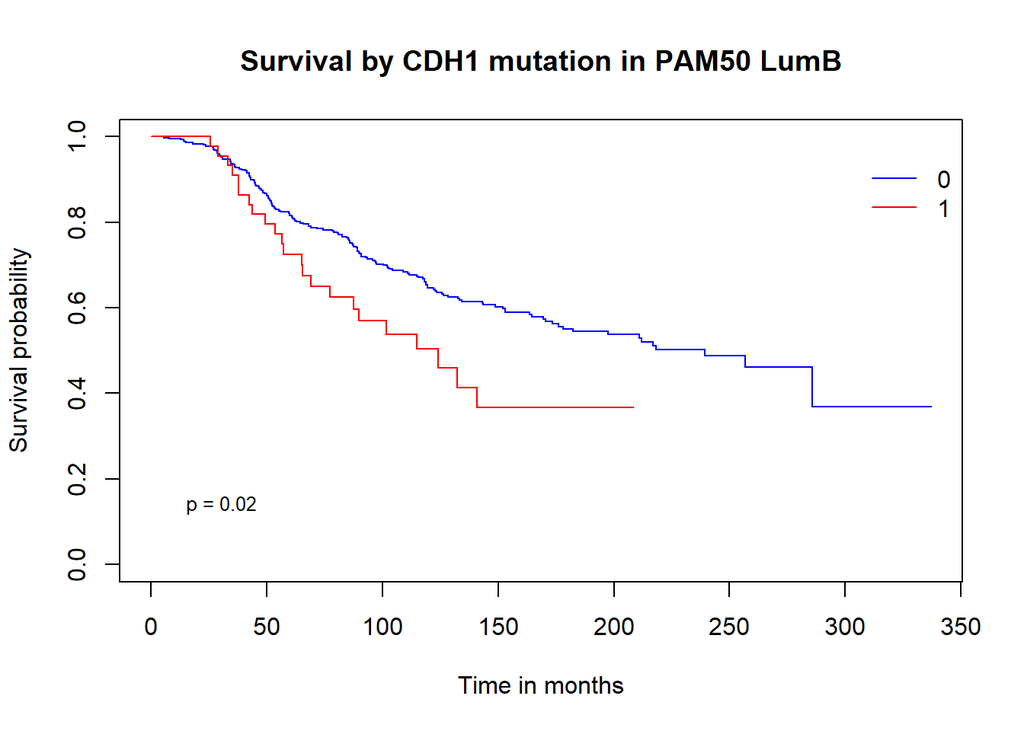

```r
##CDH1
LumB.CDH1 <- data.PAM50.LumB$CDH1
LumB.CDH1<-ifelse(is.na(LumB.CDH1), 0,1)
dfsurv <- data.frame(time, status, LumB.CDH1)
fit <- survfit(Surv(time, status) ~ LumB.CDH1, data = dfsurv)
pval <- surv_pvalue(fit)

survplot(Surv(time, status) ~ LumB.CDH1, data = dfsurv, col=c("blue", "red"), show.nrisk=F, hr.pos=NA, legend.pos = "topright", stitle=NA, cex=0.5,main = "Survival by CDH1 mutation in PAM50 LumB",ylab="Survival probability", xlab="Time in months")
legend(x=0, y=0.2, legend=as.character(pval$pval.txt), cex=0.8, box.lty = 0)
```

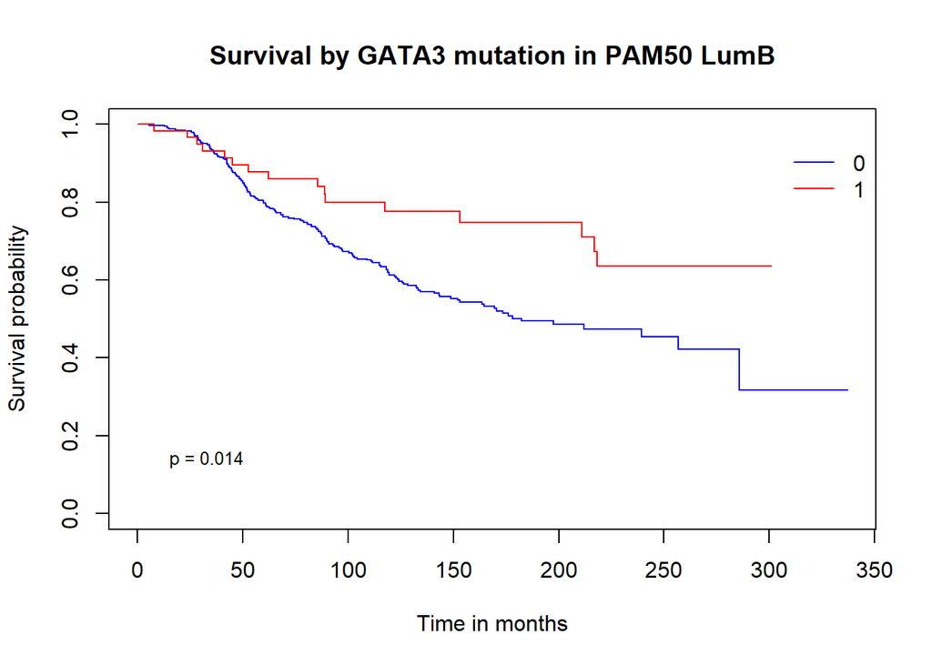

```r
##GATA3
LumB.GATA3 <- data.PAM50.LumB$GATA3
LumB.GATA3<-ifelse(is.na(LumB.GATA3), 0,1)
dfsurv <- data.frame(time, status, LumB.GATA3)
fit <- survfit(Surv(time, status) ~ LumB.GATA3, data = dfsurv)
pval <- surv_pvalue(fit)

survplot(Surv(time, status) ~ LumB.GATA3, data = dfsurv, col=c("blue", "red"), show.nrisk=F, hr.pos=NA, legend.pos = "topright", stitle=NA, cex=0.5,main = "Survival by GATA3 mutation in PAM50 LumB",ylab="Survival probability", xlab="Time in months")
legend(x=0, y=0.2, legend=as.character(pval$pval.txt), cex=0.8, box.lty = 0)
```

SUPERVIVENCIA EN EL SUBTIPO BASAL:

```r
##MUC16
data.PAM50.Basal<-data[data$Pam50Subtype=="Basal",c("Pam50Subtype","DeathBreast","T","MUC16","TP53","GATA3","PIK3CA","AHNAK2","SYNE1", "CDH1")]
status <- data.PAM50.Basal$DeathBreast
time <- data.PAM50.Basal$T/30 #tiempo en meses

Basal.MUC16 <- data.PAM50.Basal$MUC16 #datos para el gen MUC16

sum(table(Basal.MUC16)) #recuento de los que tienen mutacion (diferente a NA)
```

```
## [1] 62
```

```r
Basal.MUC16<-ifelse(is.na(Basal.MUC16), 0,1) #Ahora 1 es mutacion y 0 no.

dfsurv <- data.frame(time, status, Basal.MUC16) #Crear una tabla con las 3 variables que debemos analizar para este gen
head(dfsurv)
```

|  | time | status | Basal.MUC16 |
| --- | --- | --- | --- |
| 1 | 50.900000 | 0 | 0 |
| 2 | 44.833333 | 1 | 0 |
| 3 | 80.233333 | 0 | 0 |
| 4 | 9.133333 | 1 | 1 |
| 5 | 102.033333 | 0 | 0 |
| 6 | 106.133333 | 0 | 0 |

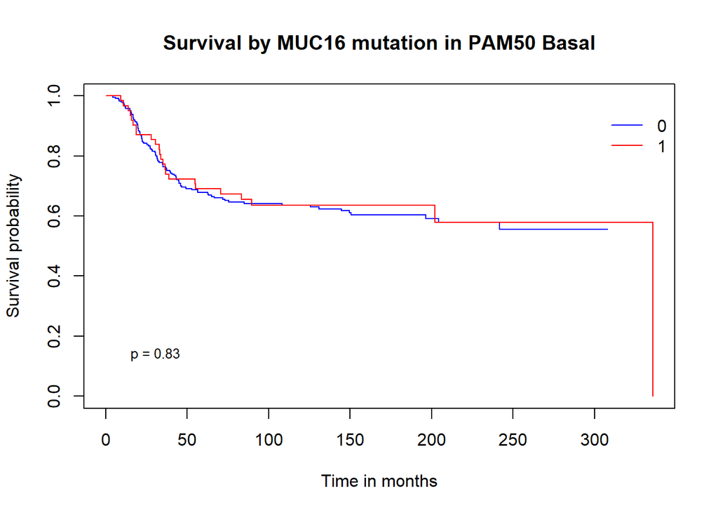

```r
fit <- survfit(Surv(time, status) ~ Basal.MUC16, data = dfsurv) #tabla con los eventos dados para pacientes mutados y no mutados en TP53

pval <- surv_pvalue(fit) #p-valor para la diferencia entre pacientes mutados y no mutados y su supervivencia

survplot(Surv(time, status) ~ Basal.MUC16, data = dfsurv, col=c("blue", "red"), show.nrisk=F, hr.pos=NA, legend.pos = "topright", stitle=NA, cex=0.5,main = "Survival by MUC16 mutation in PAM50 Basal",ylab="Survival probability", xlab="Time in months")
legend(x=0, y=0.2, legend=as.character(pval$pval.txt), cex=0.8, box.lty = 0)
```

```r
##TP53

Basal.TP53 <- data.PAM50.Basal$TP53
sum(table(Basal.TP53))
```

```
## [1] 258
```

```r
Basal.TP53<-ifelse(is.na(Basal.TP53), 0,1)
dfsurv <- data.frame(time, status, Basal.TP53)
head(dfsurv)
```

|  | time | status | Basal.TP53 |
| --- | --- | --- | --- |
| 1 | 50.900000 | 0 | 0 |
| 2 | 44.833333 | 1 | 1 |
| 3 | 80.233333 | 0 | 1 |
| 4 | 9.133333 | 1 | 1 |
| 5 | 102.033333 | 0 | 0 |
| 6 | 106.133333 | 0 | 1 |

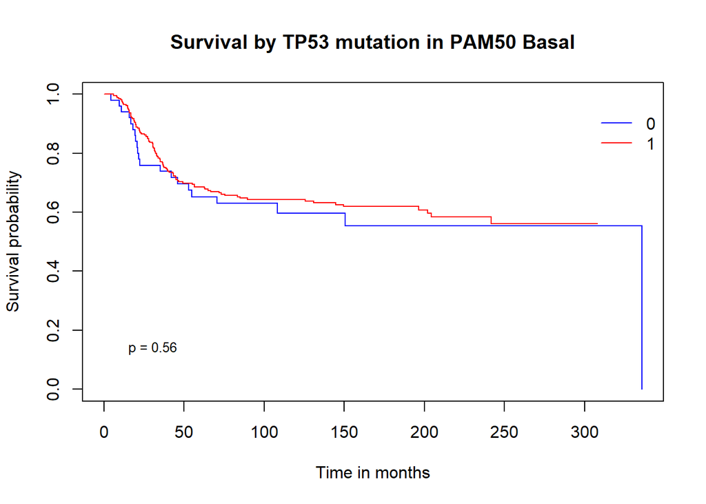

```r
fit <- survfit(Surv(time, status) ~ Basal.TP53, data = dfsurv)
pval <- surv_pvalue(fit)
survplot(Surv(time, status) ~ Basal.TP53, data = dfsurv, col=c("blue", "red"), show.nrisk=F, hr.pos=NA, legend.pos = "topright", stitle=NA, cex=0.5,main = "Survival by TP53 mutation in PAM50 Basal",ylab="Survival probability", xlab="Time in months")
legend(x=0, y=0.2, legend=as.character(pval$pval.txt), cex=0.8, box.lty = 0)
```

```r
##PIK3CA

Basal.PIK3CA <- data.PAM50.Basal$PIK3CA
sum(table(Basal.PIK3CA))
```

```
## [1] 48
```

```r
Basal.PIK3CA<-ifelse(is.na(Basal.PIK3CA), 0,1)
dfsurv <- data.frame(time, status, Basal.PIK3CA)
head(dfsurv)
```

|  | time | status | Basal.PIK3CA |
| --- | --- | --- | --- |
| 1 | 50.900000 | 0 | 0 |
| 2 | 44.833333 | 1 | 0 |
| 3 | 80.233333 | 0 | 0 |
| 4 | 9.133333 | 1 | 0 |
| 5 | 102.033333 | 0 | 0 |
| 6 | 106.133333 | 0 | 0 |

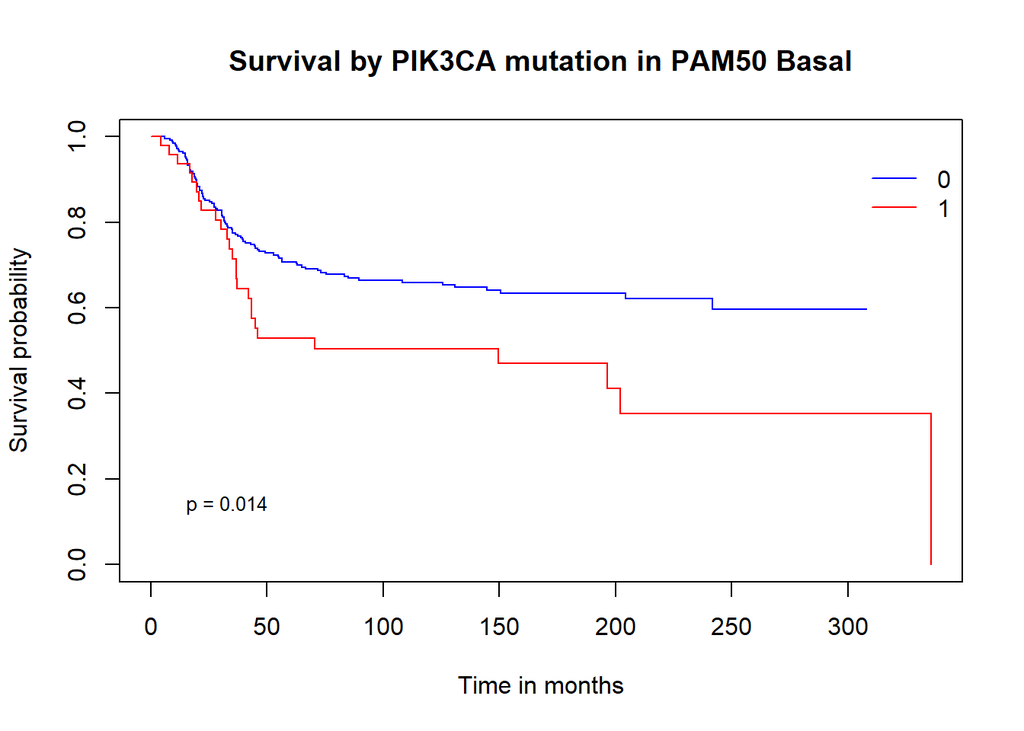

```r
fit <- survfit(Surv(time, status) ~ Basal.PIK3CA, data = dfsurv)
pval <- surv_pvalue(fit)
survplot(Surv(time, status) ~ Basal.PIK3CA, data = dfsurv, col=c("blue", "red"), show.nrisk=F, hr.pos=NA, legend.pos = "topright", stitle=NA, cex=0.5,main = "Survival by PIK3CA mutation in PAM50 Basal",ylab="Survival probability", xlab="Time in months")
legend(x=0, y=0.2, legend=as.character(pval$pval.txt), cex=0.8, box.lty = 0)
```

```r
##AHNAK2

Basal.AHNAK2 <- data.PAM50.Basal$AHNAK2
sum(table(Basal.AHNAK2))
```

```
## [1] 60
```

```r
Basal.AHNAK2<-ifelse(is.na(Basal.AHNAK2), 0,1)
dfsurv <- data.frame(time, status, Basal.AHNAK2)
head(dfsurv)
```

|  | time | status | Basal.AHNAK2 |
| --- | --- | --- | --- |
| 1 | 50.900000 | 0 | 0 |
| 2 | 44.833333 | 1 | 0 |
| 3 | 80.233333 | 0 | 0 |
| 4 | 9.133333 | 1 | 0 |
| 5 | 102.033333 | 0 | 0 |
| 6 | 106.133333 | 0 | 1 |

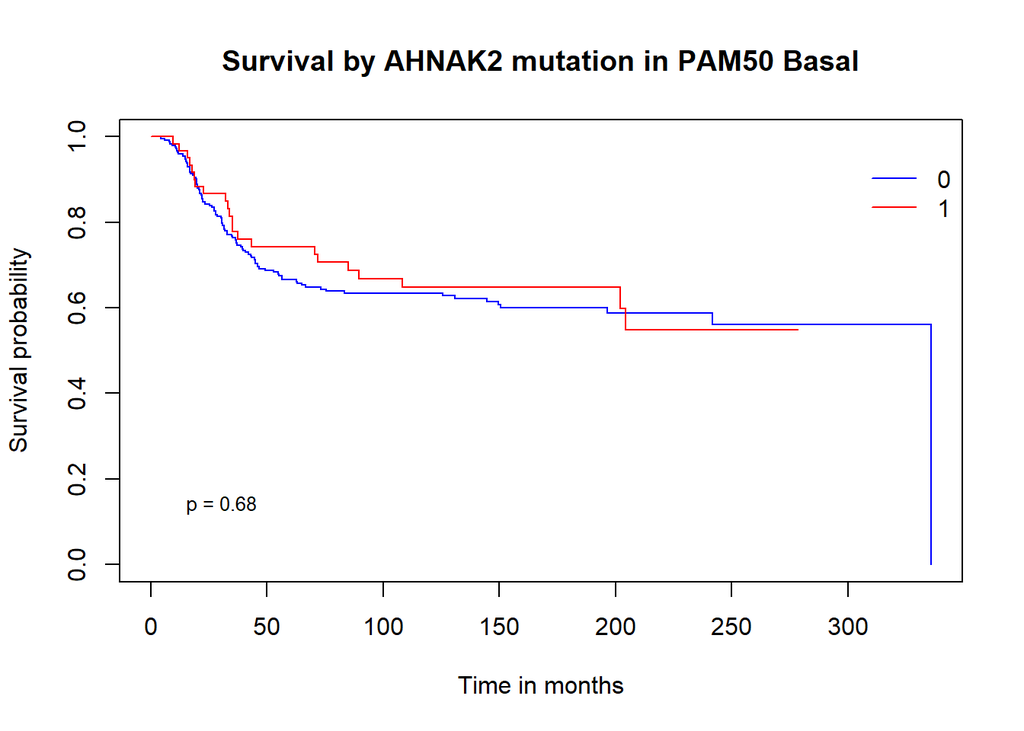

```r
fit <- survfit(Surv(time, status) ~ Basal.AHNAK2, data = dfsurv)
pval <- surv_pvalue(fit)
survplot(Surv(time, status) ~ Basal.AHNAK2, data = dfsurv, col=c("blue", "red"), show.nrisk=F, hr.pos=NA, legend.pos = "topright", stitle=NA, cex=0.5,main = "Survival by AHNAK2 mutation in PAM50 Basal",ylab="Survival probability", xlab="Time in months")
legend(x=0, y=0.2, legend=as.character(pval$pval.txt), cex=0.8, box.lty = 0)
```

```r
### SYNE1

Basal.SYNE1 <- data.PAM50.Basal$SYNE1
sum(table(Basal.SYNE1))
```

```
## [1] 54
```

```r
Basal.SYNE1<-ifelse(is.na(Basal.SYNE1), 0,1)
dfsurv <- data.frame(time, status, Basal.SYNE1)
head(dfsurv)
```

|  | time | status | Basal.SYNE1 |
| --- | --- | --- | --- |
| 1 | 50.900000 | 0 | 0 |
| 2 | 44.833333 | 1 | 0 |
| 3 | 80.233333 | 0 | 0 |
| 4 | 9.133333 | 1 | 1 |
| 5 | 102.033333 | 0 | 0 |
| 6 | 106.133333 | 0 | 0 |

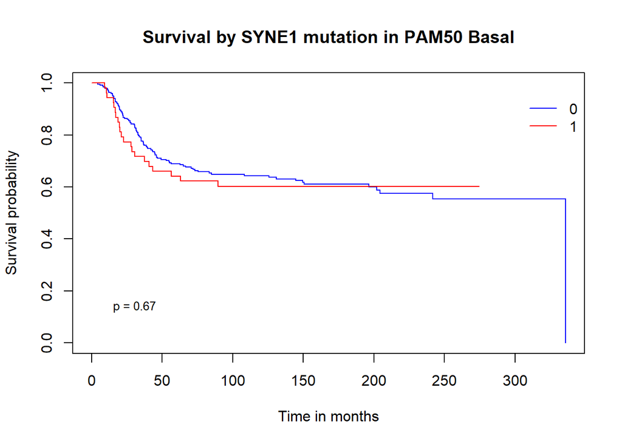

```r
fit <- survfit(Surv(time, status) ~ Basal.SYNE1, data = dfsurv)
pval <- surv_pvalue(fit)
survplot(Surv(time, status) ~ Basal.SYNE1, data = dfsurv, col=c("blue", "red"), show.nrisk=F, hr.pos=NA, legend.pos = "topright", stitle=NA, cex=0.5,main = "Survival by SYNE1 mutation in PAM50 Basal",ylab="Survival probability", xlab="Time in months")
legend(x=0, y=0.2, legend=as.character(pval$pval.txt), cex=0.8, box.lty = 0)
```

```r
###CDH1
Basal.CDH1 <- data.PAM50.Basal$CDH1
sum(table(Basal.CDH1))
```

```
## [1] 5
```

```r
Basal.CDH1<-ifelse(is.na(Basal.CDH1), 0,1)
dfsurv <- data.frame(time, status, Basal.CDH1)
head(dfsurv)
```

|  | time | status | Basal.CDH1 |
| --- | --- | --- | --- |
| 1 | 50.900000 | 0 | 0 |
| 2 | 44.833333 | 1 | 0 |
| 3 | 80.233333 | 0 | 0 |
| 4 | 9.133333 | 1 | 0 |
| 5 | 102.033333 | 0 | 0 |
| 6 | 106.133333 | 0 | 0 |

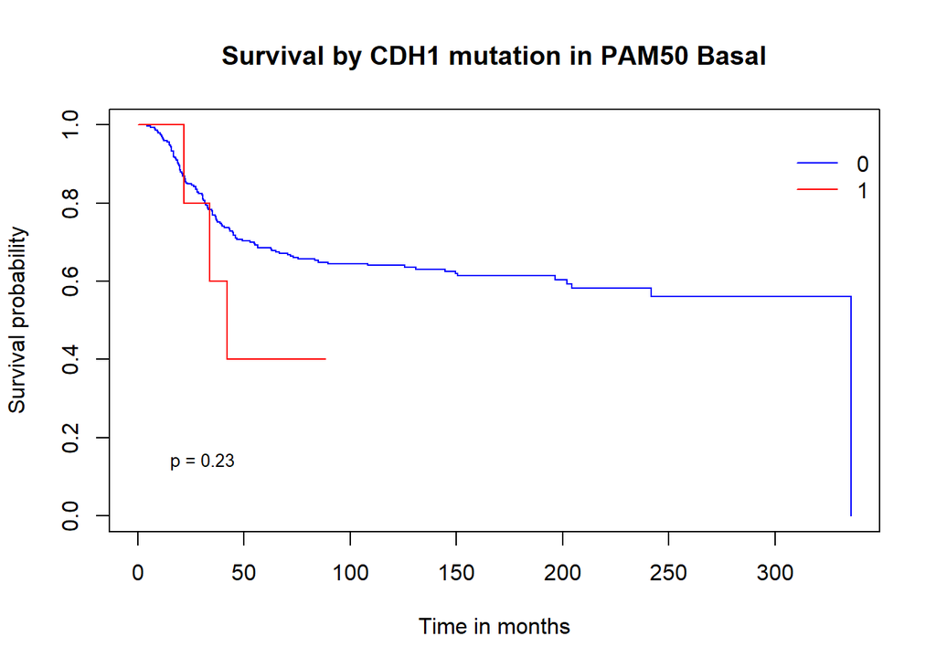

```r
fit <- survfit(Surv(time, status) ~ Basal.CDH1, data = dfsurv)
pval <- surv_pvalue(fit)
survplot(Surv(time, status) ~ Basal.CDH1, data = dfsurv, col=c("blue", "red"), show.nrisk=F, hr.pos=NA, legend.pos = "topright", stitle=NA, cex=0.5,main = "Survival by CDH1 mutation in PAM50 Basal",ylab="Survival probability", xlab="Time in months")
legend(x=0, y=0.2, legend=as.character(pval$pval.txt), cex=0.8, box.lty = 0)
```

```r
###GATA3

Basal.GATA3 <- data.PAM50.Basal$GATA3
sum(table(Basal.GATA3))
```

```
## [1] 1
```

```r
Basal.GATA3<-ifelse(is.na(Basal.GATA3), 0,1)
dfsurv <- data.frame(time, status, Basal.GATA3)
head(dfsurv)
```

|  | time | status | Basal.GATA3 |
| --- | --- | --- | --- |
| 1 | 50.900000 | 0 | 1 |
| 2 | 44.833333 | 1 | 0 |
| 3 | 80.233333 | 0 | 0 |
| 4 | 9.133333 | 1 | 0 |
| 5 | 102.033333 | 0 | 0 |
| 6 | 106.133333 | 0 | 0 |

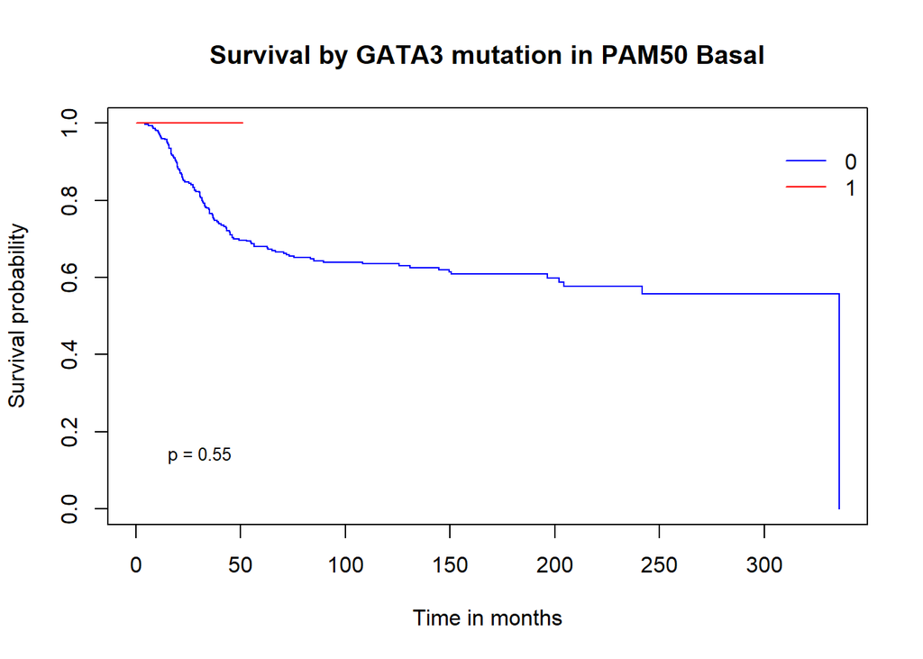

```r
fit <- survfit(Surv(time, status) ~ Basal.GATA3, data = dfsurv)
pval <- surv_pvalue(fit)
survplot(Surv(time, status) ~ Basal.GATA3, data = dfsurv, col=c("blue", "red"), show.nrisk=F, hr.pos=NA, legend.pos = "topright", stitle=NA, cex=0.5,main = "Survival by GATA3 mutation in PAM50 Basal",ylab="Survival probability", xlab="Time in months")
legend(x=0, y=0.2, legend=as.character(pval$pval.txt), cex=0.8, box.lty = 0)
```

SUPERVIVENCIA EN SUBTIPO NORMAL:

```r
data.PAM50.Normal<-data[data$Pam50Subtype=="Normal",c("Pam50Subtype","DeathBreast","T","MUC16","TP53","GATA3","PIK3CA","AHNAK2","SYNE1", "CDH1")]
status <- data.PAM50.Normal$DeathBreast
time <- data.PAM50.Normal$T/30 #tiempo en meses

Normal.MUC16 <- data.PAM50.Normal$MUC16 #datos para el gen MUC16

sum(table(Normal.MUC16)) #recuento de los que tienen mutacion (diferente a NA)
```

```
## [1] 15
```

```r
Normal.MUC16<-ifelse(is.na(Normal.MUC16), 0,1) #Ahora 1 es mutacion y 0 no.

dfsurv <- data.frame(time, status, Normal.MUC16) #Crear una tabla con las 3 variables que debemos analizar para este gen
head(dfsurv)
```

|  | time | status | Normal.MUC16 |
| --- | --- | --- | --- |
| 1 | 113.56667 | 0 | 0 |
| 2 | 257.56667 | 0 | 0 |
| 3 | 163.86667 | 0 | 0 |
| 4 | 91.23333 | 0 | 0 |
| 5 | 86.83333 | 0 | 0 |
| 6 | 269.90000 | 0 | 0 |

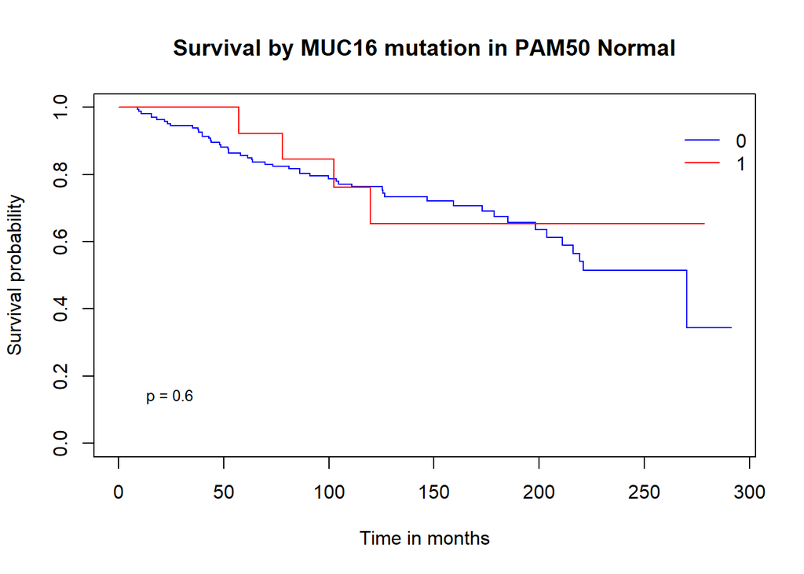

```r
fit <- survfit(Surv(time, status) ~ Normal.MUC16, data = dfsurv) #tabla con los eventos dados para pacientes mutados y no mutados en TP53

pval <- surv_pvalue(fit) #p-valor para la diferencia entre pacientes mutados y no mutados y su supervivencia

survplot(Surv(time, status) ~ Normal.MUC16, data = dfsurv, col=c("blue", "red"), show.nrisk=F, hr.pos=NA, legend.pos = "topright", stitle=NA, cex=0.5,main = "Survival by MUC16 mutation in PAM50 Normal",ylab="Survival probability", xlab="Time in months")
legend(x=0, y=0.2, legend=as.character(pval$pval.txt), cex=0.8, box.lty = 0)
```

```r
Normal.TP53 <- data.PAM50.Normal$TP53
sum(table(Normal.TP53))
```

```
## [1] 38
```

```r
Normal.TP53<-ifelse(is.na(Normal.TP53), 0,1)
dfsurv <- data.frame(time, status, Normal.TP53)
head(dfsurv)
```

|  | time | status | Normal.TP53 |
| --- | --- | --- | --- |
| 1 | 113.56667 | 0 | 0 |
| 2 | 257.56667 | 0 | 0 |
| 3 | 163.86667 | 0 | 0 |
| 4 | 91.23333 | 0 | 0 |
| 5 | 86.83333 | 0 | 0 |
| 6 | 269.90000 | 0 | 0 |

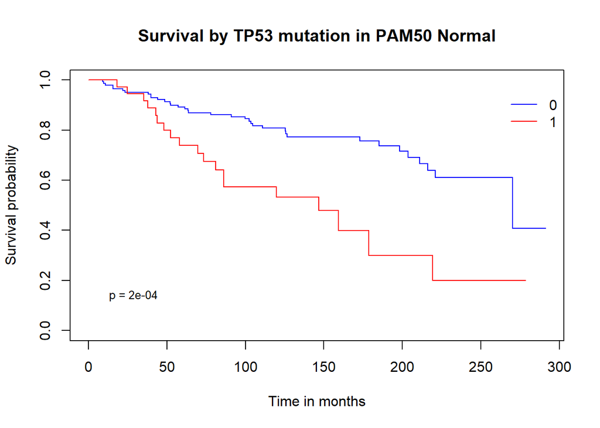

```r
fit <- survfit(Surv(time, status) ~ Normal.TP53, data = dfsurv)
pval <- surv_pvalue(fit)
survplot(Surv(time, status) ~ Normal.TP53, data = dfsurv, col=c("blue", "red"), show.nrisk=F, hr.pos=NA, legend.pos = "topright", stitle=NA, cex=0.5,main = "Survival by TP53 mutation in PAM50 Normal",ylab="Survival probability", xlab="Time in months")
legend(x=0, y=0.2, legend=as.character(pval$pval.txt), cex=0.8, box.lty = 0)
```

```r
##PIK3CA

Normal.PIK3CA <- data.PAM50.Normal$PIK3CA
sum(table(Normal.PIK3CA))
```

```
## [1] 86
```

```r
Normal.PIK3CA<-ifelse(is.na(Normal.PIK3CA), 0,1)
dfsurv <- data.frame(time, status, Normal.PIK3CA)
head(dfsurv)
```

|  | time | status | Normal.PIK3CA |
| --- | --- | --- | --- |
| 1 | 113.56667 | 0 | 1 |
| 2 | 257.56667 | 0 | 1 |
| 3 | 163.86667 | 0 | 0 |
| 4 | 91.23333 | 0 | 1 |
| 5 | 86.83333 | 0 | 1 |
| 6 | 269.90000 | 0 | 0 |

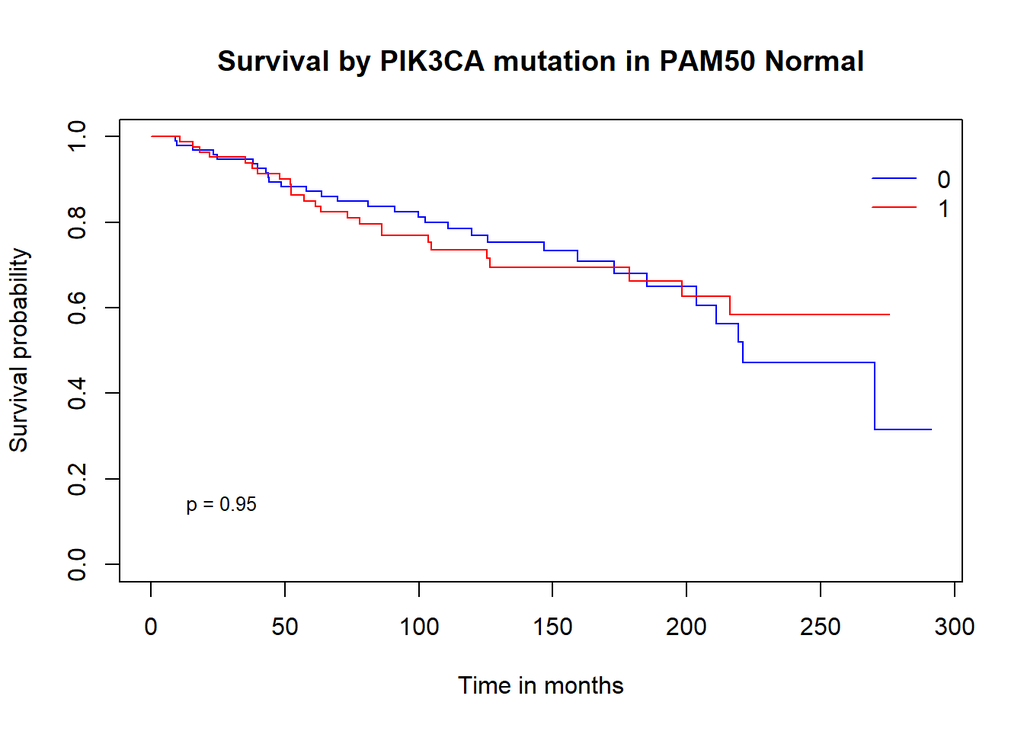

```r
fit <- survfit(Surv(time, status) ~ Normal.PIK3CA, data = dfsurv)
pval <- surv_pvalue(fit)
survplot(Surv(time, status) ~ Normal.PIK3CA, data = dfsurv, col=c("blue", "red"), show.nrisk=F, hr.pos=NA, legend.pos = "topright", stitle=NA, cex=0.5,main = "Survival by PIK3CA mutation in PAM50 Normal",ylab="Survival probability", xlab="Time in months")
legend(x=0, y=0.2, legend=as.character(pval$pval.txt), cex=0.8, box.lty = 0)
```

```r
###AHNAK2

Normal.AHNAK2 <- data.PAM50.Normal$AHNAK2
sum(table(Normal.AHNAK2))
```

```
## [1] 27
```

```r
Normal.AHNAK2<-ifelse(is.na(Normal.AHNAK2), 0,1)
dfsurv <- data.frame(time, status, Normal.AHNAK2)
head(dfsurv)
```

|  | time | status | Normal.AHNAK2 |
| --- | --- | --- | --- |
| 1 | 113.56667 | 0 | 0 |
| 2 | 257.56667 | 0 | 0 |
| 3 | 163.86667 | 0 | 1 |
| 4 | 91.23333 | 0 | 1 |
| 5 | 86.83333 | 0 | 0 |
| 6 | 269.90000 | 0 | 0 |

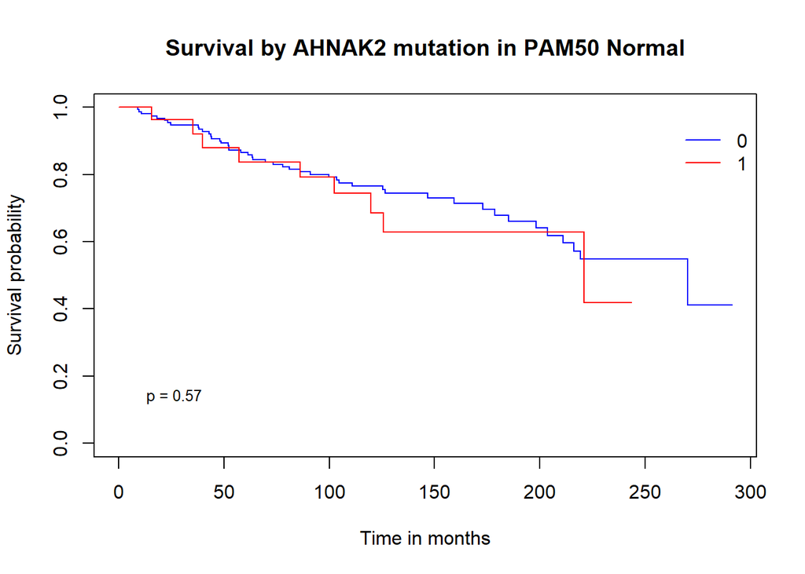

```r
fit <- survfit(Surv(time, status) ~ Normal.AHNAK2, data = dfsurv)
pval <- surv_pvalue(fit)
survplot(Surv(time, status) ~ Normal.AHNAK2, data = dfsurv, col=c("blue", "red"), show.nrisk=F, hr.pos=NA, legend.pos = "topright", stitle=NA, cex=0.5,main = "Survival by AHNAK2 mutation in PAM50 Normal",ylab="Survival probability", xlab="Time in months")
legend(x=0, y=0.2, legend=as.character(pval$pval.txt), cex=0.8, box.lty = 0)
```

```r
##SYNE1

Normal.SYNE1 <- data.PAM50.Normal$SYNE1
sum(table(Normal.SYNE1))
```

```
## [1] 15
```

```r
Normal.SYNE1<-ifelse(is.na(Normal.SYNE1), 0,1)
dfsurv <- data.frame(time, status, Normal.SYNE1)
head(dfsurv)
```

|  | time | status | Normal.SYNE1 |
| --- | --- | --- | --- |
| 1 | 113.56667 | 0 | 0 |
| 2 | 257.56667 | 0 | 0 |
| 3 | 163.86667 | 0 | 0 |
| 4 | 91.23333 | 0 | 0 |
| 5 | 86.83333 | 0 | 0 |
| 6 | 269.90000 | 0 | 1 |

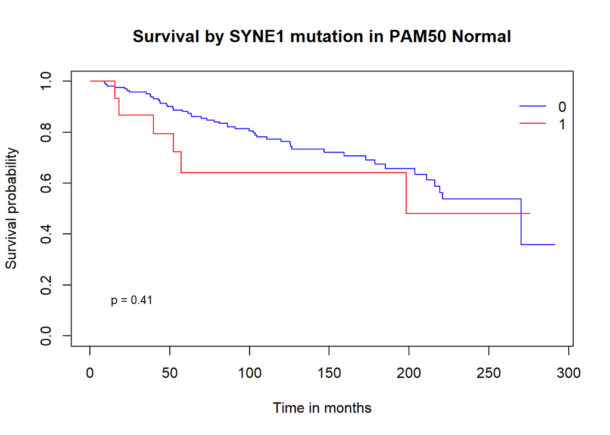

```r
fit <- survfit(Surv(time, status) ~ Normal.SYNE1, data = dfsurv)
pval <- surv_pvalue(fit)
survplot(Surv(time, status) ~ Normal.SYNE1, data = dfsurv, col=c("blue", "red"), show.nrisk=F, hr.pos=NA, legend.pos = "topright", stitle=NA, cex=0.5,main = "Survival by SYNE1 mutation in PAM50 Normal",ylab="Survival probability", xlab="Time in months")
legend(x=0, y=0.2, legend=as.character(pval$pval.txt), cex=0.8, box.lty = 0)
```

```r
#CDH1
Normal.CDH1 <- data.PAM50.Normal$CDH1
sum(table(Normal.CDH1))
```

```
## [1] 23
```

```r
Normal.CDH1<-ifelse(is.na(Normal.CDH1), 0,1)
dfsurv <- data.frame(time, status, Normal.CDH1)
head(dfsurv)
```

|  | time | status | Normal.CDH1 |
| --- | --- | --- | --- |
| 1 | 113.56667 | 0 | 0 |
| 2 | 257.56667 | 0 | 0 |
| 3 | 163.86667 | 0 | 0 |
| 4 | 91.23333 | 0 | 1 |
| 5 | 86.83333 | 0 | 0 |
| 6 | 269.90000 | 0 | 0 |

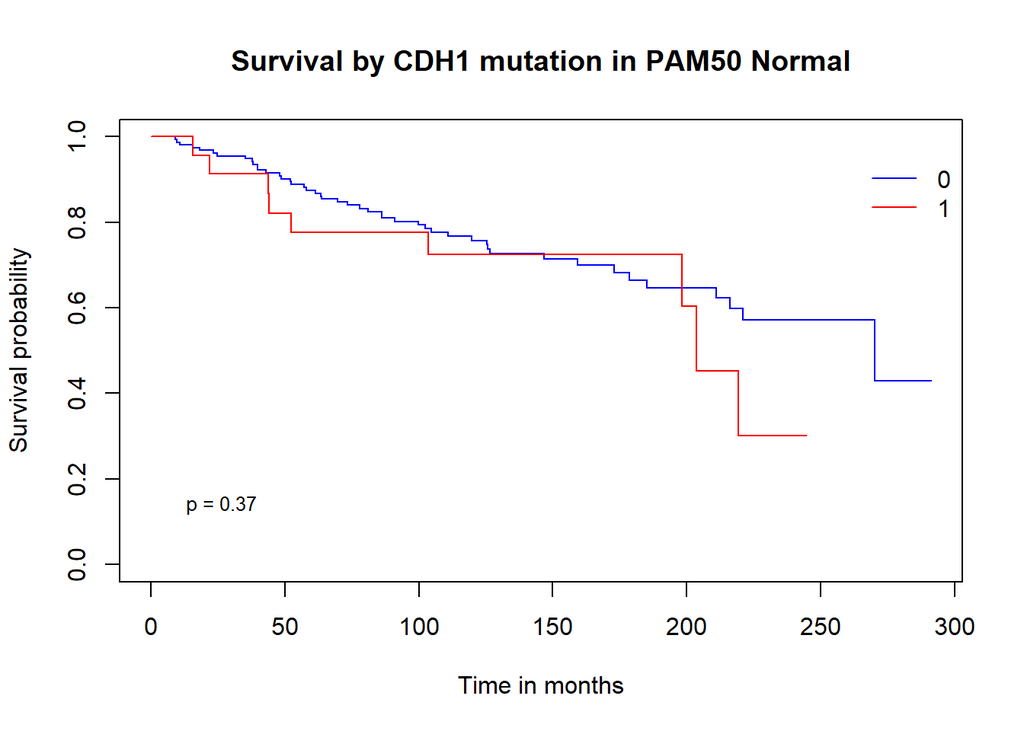

```r
fit <- survfit(Surv(time, status) ~ Normal.CDH1, data = dfsurv)
pval <- surv_pvalue(fit)
survplot(Surv(time, status) ~ Normal.CDH1, data = dfsurv, col=c("blue", "red"), show.nrisk=F, hr.pos=NA, legend.pos = "topright", stitle=NA, cex=0.5,main = "Survival by CDH1 mutation in PAM50 Normal",ylab="Survival probability", xlab="Time in months")
legend(x=0, y=0.2, legend=as.character(pval$pval.txt), cex=0.8, box.lty = 0)
```

```r
###GATA3

Normal.GATA3 <- data.PAM50.Normal$GATA3
sum(table(Normal.GATA3))
```

```
## [1] 14
```

```r
Normal.GATA3<-ifelse(is.na(Normal.GATA3), 0,1)
dfsurv <- data.frame(time, status, Normal.GATA3)
head(dfsurv)
```

|  | time | status | Normal.GATA3 |
| --- | --- | --- | --- |
| 1 | 113.56667 | 0 | 0 |
| 2 | 257.56667 | 0 | 0 |
| 3 | 163.86667 | 0 | 0 |
| 4 | 91.23333 | 0 | 0 |
| 5 | 86.83333 | 0 | 0 |
| 6 | 269.90000 | 0 | 0 |

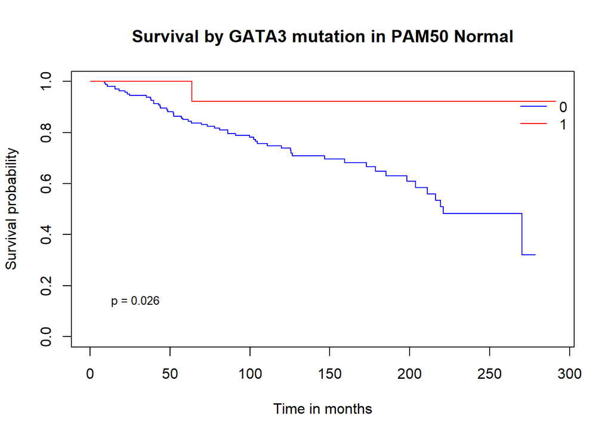

```r
fit <- survfit(Surv(time, status) ~ Normal.GATA3, data = dfsurv)
pval <- surv_pvalue(fit)
survplot(Surv(time, status) ~ Normal.GATA3, data = dfsurv, col=c("blue", "red"), show.nrisk=F, hr.pos=NA, legend.pos = "topright", stitle=NA, cex=0.5,main = "Survival by GATA3 mutation in PAM50 Normal",ylab="Survival probability", xlab="Time in months")
legend(x=0, y=0.2, legend=as.character(pval$pval.txt), cex=0.8, box.lty = 0)
```

SUPERVIVENCIA EN HER2:

```r
##MUC16

data.PAM50.Her2<-data[data$Pam50Subtype=="Her2",c("Pam50Subtype","DeathBreast","T","MUC16","TP53","GATA3","PIK3CA","AHNAK2","SYNE1", "CDH1")]
status <- data.PAM50.Her2$DeathBreast
time <- data.PAM50.Her2$T/30

Her2.MUC16 <- data.PAM50.Her2$MUC16
sum(table(Her2.MUC16))
```

```
## [1] 62
```

```r
Her2.MUC16<-ifelse(is.na(Her2.MUC16), 0,1)

dfsurv <- data.frame(time, status, Her2.MUC16)
head(dfsurv)
```

|  | time | status | Her2.MUC16 |
| --- | --- | --- | --- |
| 1 | 110.76667 | 1 | 0 |
| 2 | 88.46667 | 0 | 0 |
| 3 | 123.53333 | 0 | 1 |
| 4 | 98.26667 | 0 | 0 |
| 5 | 39.53333 | 1 | 1 |
| 6 | 45.80000 | 1 | 0 |

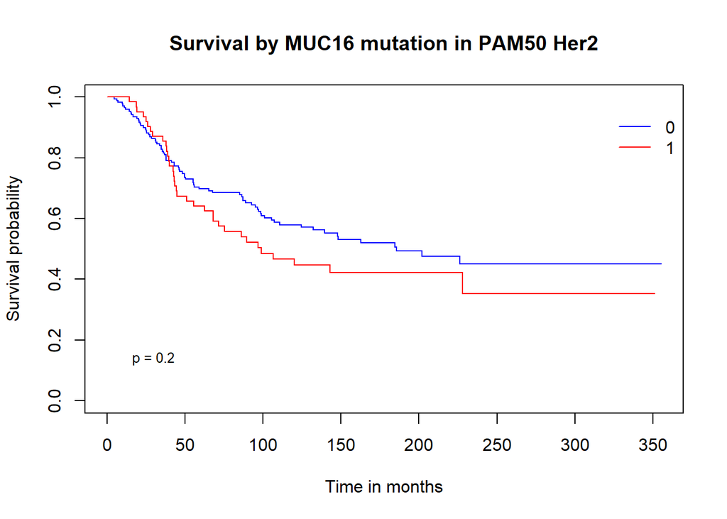

```r
fit <- survfit(Surv(time, status) ~ Her2.MUC16, data = dfsurv)

pval <- surv_pvalue(fit)

survplot(Surv(time, status) ~ Her2.MUC16, data = dfsurv, col=c("blue", "red"), show.nrisk=F, hr.pos=NA, legend.pos = "topright", stitle=NA, cex=0.5,main = "Survival by MUC16 mutation in PAM50 Her2",ylab="Survival probability", xlab="Time in months")
legend(x=0, y=0.2, legend=as.character(pval$pval.txt), cex=0.8, box.lty = 0)
```

```r
##TP53
Her2.TP53<- data.PAM50.Her2$TP53
sum(table(Her2.TP53))
```

```
## [1] 164
```

```r
Her2.TP53<-ifelse(is.na(Her2.TP53), 0,1)

dfsurv <- data.frame(time, status, Her2.TP53)
head(dfsurv)
```

|  | time | status | Her2.TP53 |
| --- | --- | --- | --- |
| 1 | 110.76667 | 1 | 0 |
| 2 | 88.46667 | 0 | 1 |
| 3 | 123.53333 | 0 | 1 |
| 4 | 98.26667 | 0 | 1 |
| 5 | 39.53333 | 1 | 1 |
| 6 | 45.80000 | 1 | 1 |

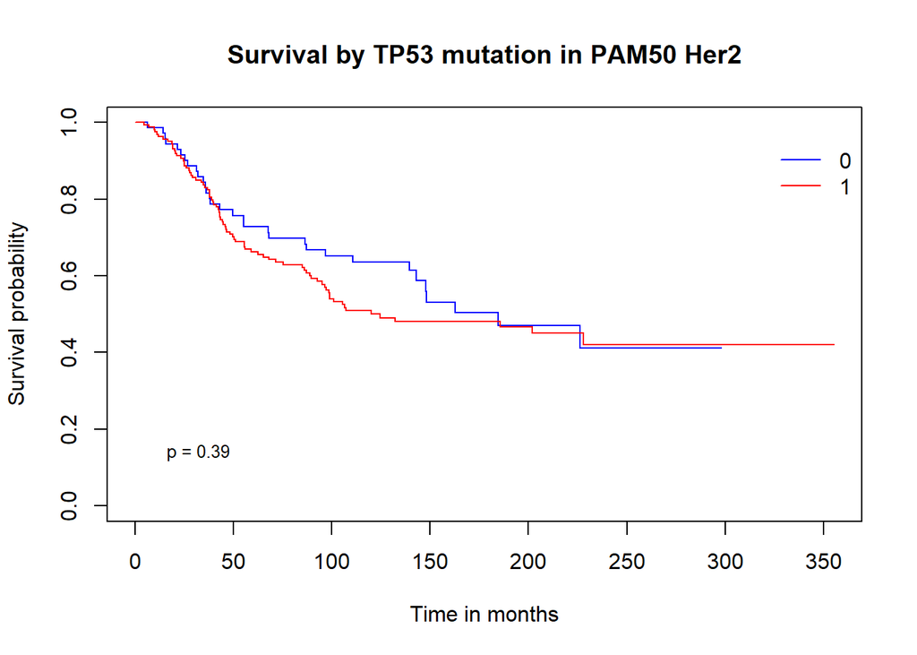

```r
fit <- survfit(Surv(time, status) ~ Her2.TP53, data = dfsurv)

pval <- surv_pvalue(fit)

survplot(Surv(time, status) ~ Her2.TP53, data = dfsurv, col=c("blue", "red"), show.nrisk=F, hr.pos=NA, legend.pos = "topright", stitle=NA, cex=0.5,main = "Survival by TP53 mutation in PAM50 Her2",ylab="Survival probability", xlab="Time in months")
legend(x=0, y=0.2, legend=as.character(pval$pval.txt), cex=0.8, box.lty = 0)
```

```r
###PIK3CA

Her2.PIK3CA <- data.PAM50.Her2$PIK3CA
sum(table(Her2.PIK3CA))
```

```
## [1] 96
```

```r
Her2.PIK3CA<-ifelse(is.na(Her2.PIK3CA), 0,1)

dfsurv <- data.frame(time, status, Her2.PIK3CA)
head(dfsurv)
```

|  | time | status | Her2.PIK3CA |
| --- | --- | --- | --- |
| 1 | 110.76667 | 1 | 0 |
| 2 | 88.46667 | 0 | 0 |
| 3 | 123.53333 | 0 | 0 |
| 4 | 98.26667 | 0 | 0 |
| 5 | 39.53333 | 1 | 0 |
| 6 | 45.80000 | 1 | 1 |

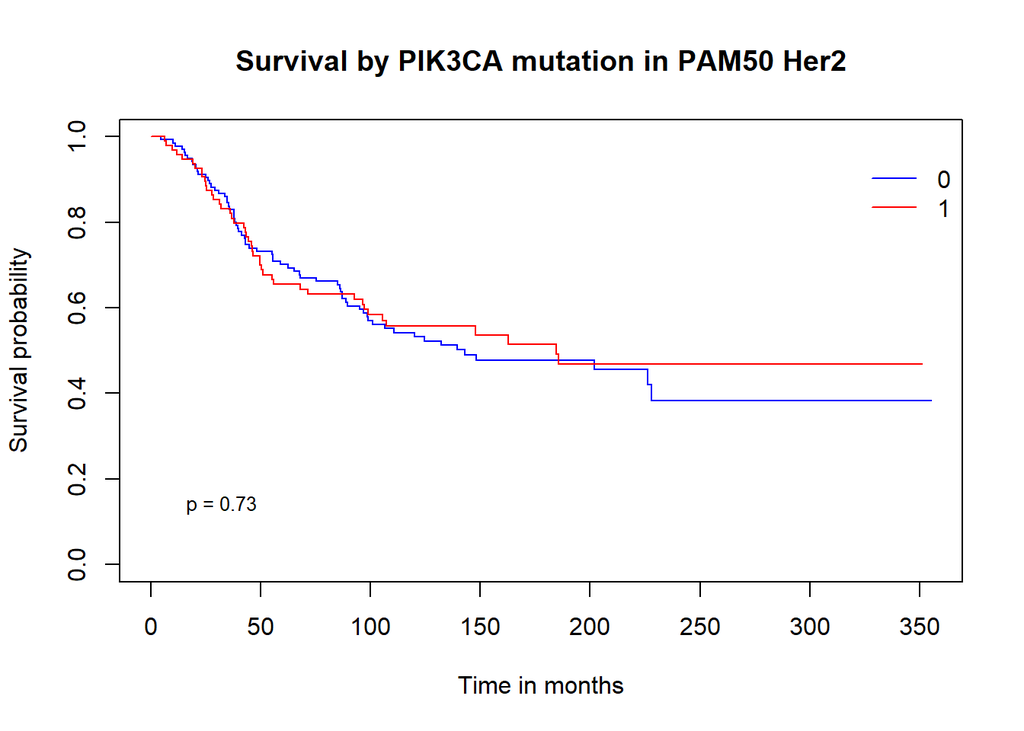

```r
fit <- survfit(Surv(time, status) ~ Her2.PIK3CA, data = dfsurv)

pval <- surv_pvalue(fit)

survplot(Surv(time, status) ~ Her2.PIK3CA, data = dfsurv, col=c("blue", "red"), show.nrisk=F, hr.pos=NA, legend.pos = "topright", stitle=NA, cex=0.5,main = "Survival by PIK3CA mutation in PAM50 Her2",ylab="Survival probability", xlab="Time in months")
legend(x=0, y=0.2, legend=as.character(pval$pval.txt), cex=0.8, box.lty = 0)
```

```r
###AHNAK2
Her2.AHNAK2 <- data.PAM50.Her2$AHNAK2
sum(table(Her2.AHNAK2))
```

```
## [1] 48
```

```r
Her2.AHNAK2<-ifelse(is.na(Her2.AHNAK2), 0,1)

dfsurv <- data.frame(time, status, Her2.AHNAK2)
head(dfsurv)
```

|  | time | status | Her2.AHNAK2 |
| --- | --- | --- | --- |
| 1 | 110.76667 | 1 | 0 |
| 2 | 88.46667 | 0 | 1 |
| 3 | 123.53333 | 0 | 0 |
| 4 | 98.26667 | 0 | 0 |
| 5 | 39.53333 | 1 | 0 |
| 6 | 45.80000 | 1 | 0 |

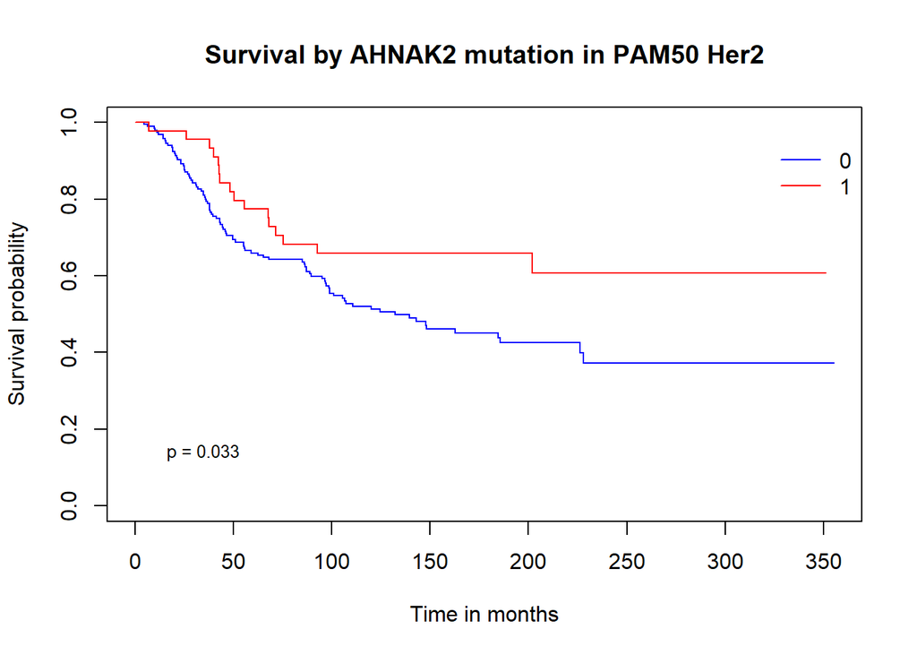

```r
fit <- survfit(Surv(time, status) ~ Her2.AHNAK2, data = dfsurv)

pval <- surv_pvalue(fit)

survplot(Surv(time, status) ~ Her2.AHNAK2, data = dfsurv, col=c("blue", "red"), show.nrisk=F, hr.pos=NA, legend.pos = "topright", stitle=NA, cex=0.5,main = "Survival by AHNAK2 mutation in PAM50 Her2",ylab="Survival probability", xlab="Time in months")
legend(x=0, y=0.2, legend=as.character(pval$pval.txt), cex=0.8, box.lty = 0)
```

```r
###SYNE1

Her2.SYNE1<- data.PAM50.Her2$SYNE1
sum(table(Her2.SYNE1))
```

```
## [1] 41
```

```r
Her2.SYNE1<-ifelse(is.na(Her2.SYNE1), 0,1)

dfsurv <- data.frame(time, status, Her2.SYNE1)
head(dfsurv)
```

|  | time | status | Her2.SYNE1 |
| --- | --- | --- | --- |
| 1 | 110.76667 | 1 | 1 |
| 2 | 88.46667 | 0 | 0 |
| 3 | 123.53333 | 0 | 0 |
| 4 | 98.26667 | 0 | 0 |
| 5 | 39.53333 | 1 | 0 |
| 6 | 45.80000 | 1 | 0 |

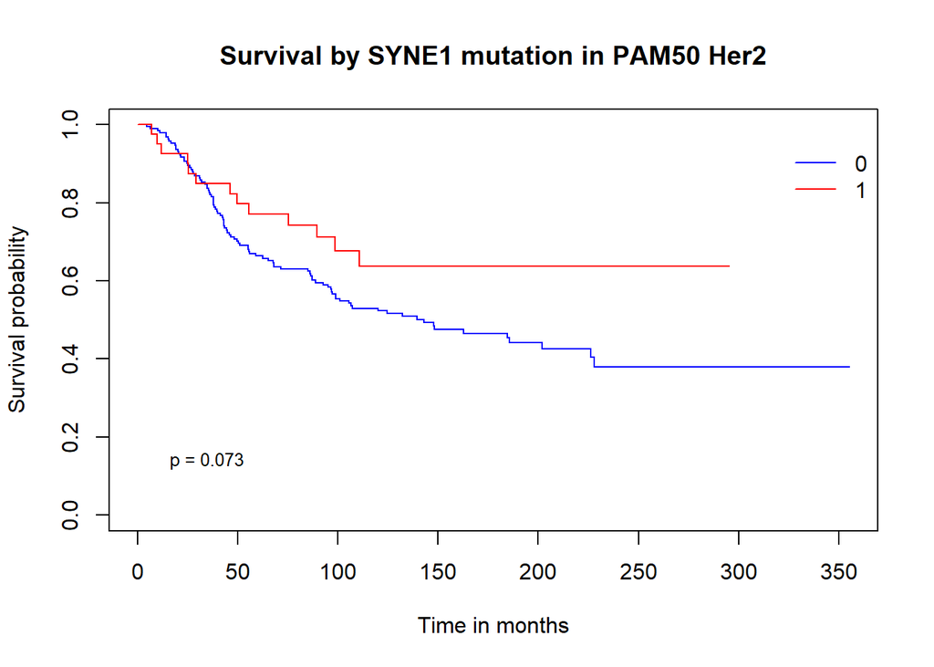

```r
fit <- survfit(Surv(time, status) ~ Her2.SYNE1, data = dfsurv)
pval <- surv_pvalue(fit)

survplot(Surv(time, status) ~ Her2.SYNE1, data = dfsurv, col=c("blue", "red"), show.nrisk=F, hr.pos=NA, legend.pos = "topright", stitle=NA, cex=0.5,main = "Survival by SYNE1 mutation in PAM50 Her2",ylab="Survival probability", xlab="Time in months")
legend(x=0, y=0.2, legend=as.character(pval$pval.txt), cex=0.8, box.lty = 0)
```

```r
###CDH1

Her2.CDH1 <- data.PAM50.Her2$CDH1
sum(table(Her2.MUC16))
```

```
## [1] 242
```

```r
Her2.CDH1<-ifelse(is.na(Her2.CDH1), 0,1)

dfsurv <- data.frame(time, status, Her2.CDH1)
head(dfsurv)
```

|  | time | status | Her2.CDH1 |
| --- | --- | --- | --- |
| 1 | 110.76667 | 1 | 0 |
| 2 | 88.46667 | 0 | 0 |
| 3 | 123.53333 | 0 | 0 |
| 4 | 98.26667 | 0 | 0 |
| 5 | 39.53333 | 1 | 0 |
| 6 | 45.80000 | 1 | 0 |

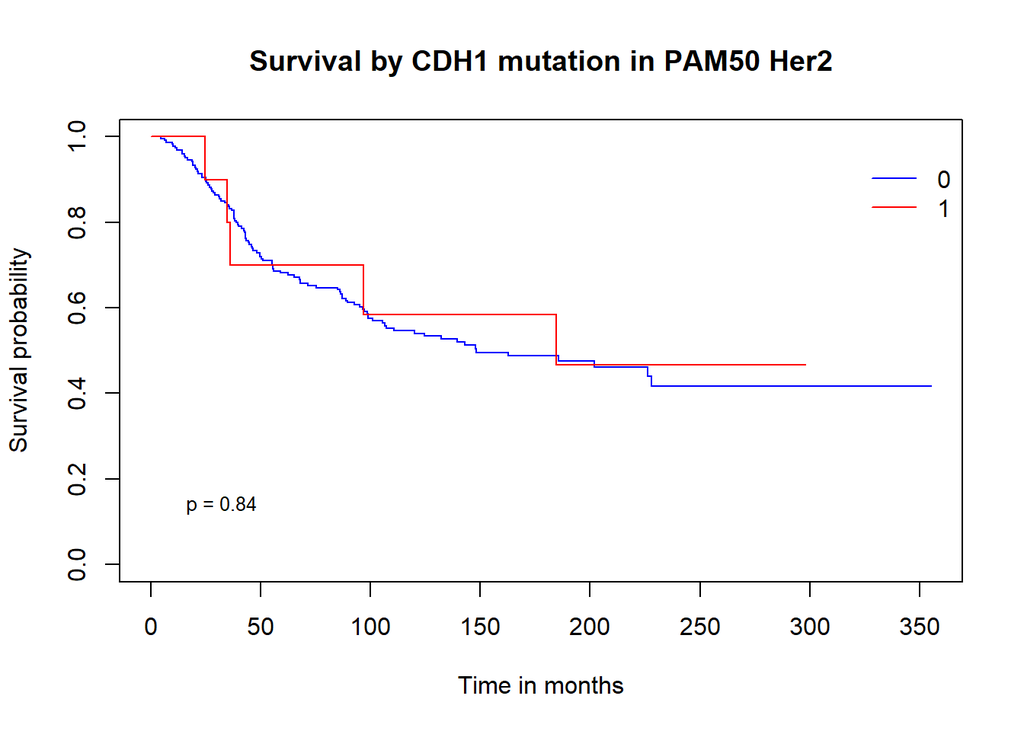

```r
fit <- survfit(Surv(time, status) ~ Her2.CDH1, data = dfsurv)

pval <- surv_pvalue(fit)

survplot(Surv(time, status) ~ Her2.CDH1, data = dfsurv, col=c("blue", "red"), show.nrisk=F, hr.pos=NA, legend.pos = "topright", stitle=NA, cex=0.5,main = "Survival by CDH1 mutation in PAM50 Her2",ylab="Survival probability", xlab="Time in months")
legend(x=0, y=0.2, legend=as.character(pval$pval.txt), cex=0.8, box.lty = 0)
```

```r
###GATA3

Her2.GATA3 <- data.PAM50.Her2$GATA3
sum(table(Her2.GATA3))
```

```
## [1] 17
```

```r
Her2.GATA3<-ifelse(is.na(Her2.GATA3), 0,1)
dfsurv <- data.frame(time, status, Her2.GATA3)
head(dfsurv)
```

|  | time | status | Her2.GATA3 |
| --- | --- | --- | --- |
| 1 | 110.76667 | 1 | 0 |
| 2 | 88.46667 | 0 | 0 |
| 3 | 123.53333 | 0 | 0 |
| 4 | 98.26667 | 0 | 0 |
| 5 | 39.53333 | 1 | 1 |
| 6 | 45.80000 | 1 | 0 |

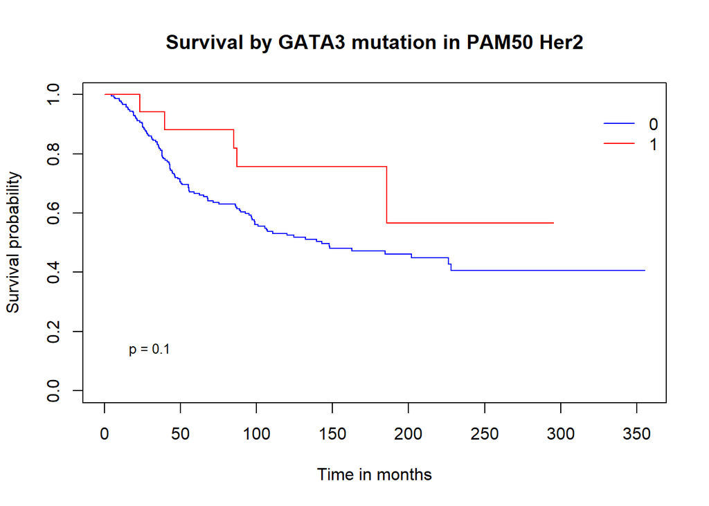

```r
fit <- survfit(Surv(time, status) ~ Her2.GATA3, data = dfsurv)

pval <- surv_pvalue(fit)

survplot(Surv(time, status) ~ Her2.GATA3, data = dfsurv, col=c("blue", "red"), show.nrisk=F, hr.pos=NA, legend.pos = "topright", stitle=NA, cex=0.5,main = "Survival by GATA3 mutation in PAM50 Her2",ylab="Survival probability", xlab="Time in months")
legend(x=0, y=0.2, legend=as.character(pval$pval.txt), cex=0.8, box.lty = 0)
```

Segun lo obtenido, para cada subtipo los genes que han supuesto una variacion significativa en cuanto a supervivencia son:

LumA: TP53, P-valor= 0.0028 GATA3, p-valor= 0.037

Basal: PIK3CA, p-valor= 0.014

Normal:

TP53, P-valor= 2*10-4 GATA3, p-valor= 0.026

Her2: AHNAK2, p-valor= 0.033